# Homework

```r
library(BL22204010)
library(ggplot2)
```

## Homework 0

## Data Generation

For example 1, a regular sequence of integers from 1 to 30 can be generated like this:

```r
 x <- 1:30
x
```

```
#>  [1]  1  2  3  4  5  6  7  8  9 10 11 12 13 14 15 16 17 18 19 20 21 22 23 24 25
#> [26] 26 27 28 29 30
```

## Explain

The resulting vector x has 30 elements.

## For example 2

Function Generate different levels of data (gl) is very useful because it can generate a regular sequence of factors. The usage of this function is gl(k,n), where k is the number of levels (or categories) and n is the number of times each level is repeated. This function has two options: length is used to specify the number of data to generate, and labels is used to specify the name of each level factor.

```r
gl(2, 6, label=c("Male", "Female"))
```

```
#>  [1] Male   Male   Male   Male   Male   Male   Female Female Female Female
#> [11] Female Female
#> Levels: Male Female
```

```r
expand.grid(Hight=c(60,80), Width=c(100, 300), sex=c("Male", "Female"))
```

```
#>   Hight Width    sex
#> 1    60   100   Male
#> 2    80   100   Male
#> 3    60   300   Male
#> 4    80   300   Male
#> 5    60   100 Female
#> 6    80   100 Female
#> 7    60   300 Female
#> 8    80   300 Female
```

## Examples 3

The time-series function (ts) creates a ts-type object from a vector (univariate time series), and has some options (with default values) that indicate the characteristics of the series.

```r
ts(1:47, frequency = 12, start = c(1959, 2))
```

```
#>      Jan Feb Mar Apr May Jun Jul Aug Sep Oct Nov Dec
#> 1959       1   2   3   4   5   6   7   8   9  10  11
#> 1960  12  13  14  15  16  17  18  19  20  21  22  23
#> 1961  24  25  26  27  28  29  30  31  32  33  34  35
#> 1962  36  37  38  39  40  41  42  43  44  45  46  47
```

## Homework 1

## Question 3.4 (pages 94-96, Statistical Computating with R)

## Answer 3.4

To generate random samples from a Rayleigh distribution, we can use the fact that if $X$ follows a Rayleigh distribution with parameter $\sigma$, then the square of $X$ follows an exponential distribution with rate $\lambda = \frac{1}{2 \sigma^2}$. Specifically, for a Rayleigh distribution, we can generate samples using the following steps:

Alternatively, we can generate the Rayleigh random sample by using the relationship with the chi-squared distribution:

$$X = \sigma \sqrt{-2 \ln(U)},$$
where $U \sim \text{Uniform}(0,1)$.

**Algorithm for Generating Rayleigh Samples:**

- $\sigma > 0$, the scale parameter of the Rayleigh distribution, and $n$, the number of samples to generate. - A vector of Rayleigh-distributed random variables.
- Generate $n$ independent random variables $U_1, U_2, \dots, U_n$ from the uniform distribution $\text{Uniform}(0,1)$.
- For each $U_i$, compute $X_i = \sigma \sqrt{-2 \ln(U_i)}$.
- Return the vector of $X_i$’s.

```r
# Function to generate Rayleigh distributed random samples
generate_rayleigh <- function(n, sigma) {
  # Generate n uniform random variables
  U <- runif(n)
  # Apply the Rayleigh transformation
  X <- sigma * sqrt(-2 * log(U))
  return(X)
}

# Function to check the mode of the generated samples
check_mode <- function(samples, sigma) {
  mode_theoretical <- sigma  # Theoretical mode of Rayleigh distribution
  mode_sample <- density(samples)$x[which.max(density(samples)$y)]  # Sample mode using density estimation
  cat("Theoretical mode: ", mode_theoretical, "\n")
  cat("Sample mode: ", mode_sample, "\n")
}

# Example: Generate Rayleigh samples for different sigma values
set.seed(123)  # For reproducibility
sigma_values <- c(1, 2, 3)  # Different values for sigma
n <- 10000  # Number of samples

# Increase plot margins
par(mfrow = c(2, 2), mar = c(4, 4, 2, 1))  # Set up a 2x2 plotting area with adjusted margins

for (sigma in sigma_values) {
  samples <- generate_rayleigh(n, sigma)
  hist(samples, probability = TRUE, main = paste("Histogram of Rayleigh(", sigma, ")"),
       xlab = "x", col = "lightblue", breaks = 50)
  check_mode(samples, sigma)
}
```

```
#> Theoretical mode:  1
#> Sample mode:  0.9975599
#> Theoretical mode:  2
#> Sample mode:  2.366148
#> Theoretical mode:  3
#> Sample mode:  2.776427
```

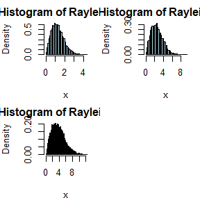

```r
# Reset plotting parameters after use
par(mfrow = c(1, 1))  # Reset to single-plot layout
```

## Question 3.11 (pages 94-96, Statistical Computating with R)

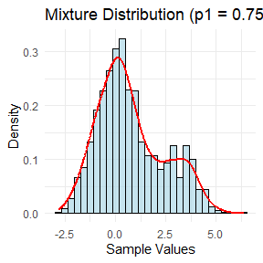

```r
# Load necessary library
library(ggplot2)

# Function to generate random sample from a mixture of two normal distributions
generate_mixture_sample <- function(n, p1) {
  # Probabilities for components
  p2 <- 1 - p1

  # Generate random component choices based on probabilities
  component_choices <- sample(c(1, 2), size = n, replace = TRUE, prob = c(p1, p2))

  # Generate samples from N(0, 1) and N(3, 1)
  sample_1 <- rnorm(sum(component_choices == 1), mean = 0, sd = 1)
  sample_2 <- rnorm(sum(component_choices == 2), mean = 3, sd = 1)

  # Combine the samples
  mixture_sample <- c(sample_1, sample_2)

  return(mixture_sample)
}

# Generate and visualize the mixture sample for p1 = 0.75
set.seed(123)
n <- 1000
p1 <- 0.75
mixture_sample <- generate_mixture_sample(n, p1)

# Plot histogram with density overlay using ggplot2
ggplot(data.frame(x = mixture_sample), aes(x = x)) +
  geom_histogram(aes(y = ..density..), bins = 30, fill = "lightblue", color = "black", alpha = 0.7) +
  geom_density(color = "red", size = 1) +
  labs(title = paste("Mixture Distribution (p1 =", p1, ")"), x = "Sample Values", y = "Density") +
  theme_minimal()
```

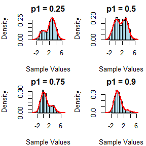

```r
# Repeat the process for other values of p1 using base R plots
p1_values <- c(0.25, 0.5, 0.75, 0.9)

# Set up a 2x2 plotting area
par(mfrow = c(2, 2), mar = c(4, 4, 2, 1))  # Adjust margins for better layout

for (p1 in p1_values) {
  mixture_sample <- generate_mixture_sample(n, p1)

  # Plot histogram with density overlay using base R
  hist(
    mixture_sample, probability = TRUE, main = paste("p1 =", p1),
    xlab = "Sample Values", col = "lightblue", border = "black", breaks = 30
  )
  lines(density(mixture_sample), col = "red", lwd = 2)
}
```

```r
# Reset plotting layout to default
par(mfrow = c(1, 1))
```

## Question 3.20 (pages 94-96, Statistical Computating with R)

```r
# Load necessary libraries
library(ggplot2)

# Function to simulate a Compound Poisson-Gamma process
simulate_compound_poisson_gamma <- function(lambda, alpha, beta, t, n_sim) {
  means <- numeric(n_sim)
  variances <- numeric(n_sim)

  # Simulate the process n_sim times
  for (i in 1:n_sim) {
    # Simulate the Poisson process N(t)
    N_t <- rpois(1, lambda * t)  # Poisson process with rate lambda

    # Generate jumps from Gamma distribution
    Y <- rgamma(N_t, shape = alpha, rate = beta)

    # Compute the sum X(t)
    X_t <- sum(Y)

    # Estimate mean and variance
    means[i] <- X_t
    variances[i] <- var(Y) * N_t  # Variance of the sum of N_t gamma variables
  }

  # Calculate theoretical mean and variance
  theoretical_mean <- lambda * t * alpha / beta
  theoretical_variance <- lambda * t * (alpha / beta^2 + (alpha / beta)^2)

  # Return results
  list(mean_estimate = mean(means),
       variance_estimate = mean(variances),
       theoretical_mean = theoretical_mean,
       theoretical_variance = theoretical_variance)
}

# Set parameters for simulation
lambda <- 2  # Poisson rate
alpha <- 3   # Gamma shape parameter
beta <- 1    # Gamma rate parameter
t <- 10      # Time point to evaluate X(t)
n_sim <- 1000  # Number of simulations

# Run the simulation
results <- simulate_compound_poisson_gamma(lambda, alpha, beta, t, n_sim)

# Display results
cat("Estimated Mean of X(10):", results$mean_estimate, "\n")
```

```
#> Estimated Mean of X(10): 60.26144
```

```r
cat("Estimated Variance of X(10):", results$variance_estimate, "\n")
```

```
#> Estimated Variance of X(10): 59.82358
```

```r
cat("Theoretical Mean of X(10):", results$theoretical_mean, "\n")
```

```
#> Theoretical Mean of X(10): 60
```

```r
cat("Theoretical Variance of X(10):", results$theoretical_variance, "\n")
```

```
#> Theoretical Variance of X(10): 240
```

## Homework 2 (pages 149-151, Statistical Computing with R).

## Exercise 5.4

Write a function to compute a Monte Carlo estimate of the $\text{Beta}(3, 3)$ cdf, and use the function to estimate $F(x)$ for $x = 0.1, 0.2, \dots, 0.9$. Compare the estimates with the values returned by the function in .

## Answer 5.4

```r
# Function to estimate the Beta(3, 3) CDF using Monte Carlo simulation
monte_carlo_beta_cdf <- function(x, n_sim) {
  # Generate n_sim samples from Beta(3, 3)
  samples <- rbeta(n_sim, shape1 = 3, shape2 = 3)
  # Estimate the CDF as the proportion of samples <= x
  estimate <- mean(samples <= x)
  return(estimate)
}

# Parameters
n_sim <- 10000  # Number of simulations
x_values <- seq(0.1, 0.9, by = 0.1)  # x values to estimate

# Compute estimates and compare with pbeta
estimates <- sapply(x_values, monte_carlo_beta_cdf, n_sim = n_sim)
pbeta_values <- pbeta(x_values, shape1 = 3, shape2 = 3)

# Results
results <- data.frame(x = x_values, Monte_Carlo_Estimate = estimates, pbeta_Values = pbeta_values)
print(results)
```

```
#>     x Monte_Carlo_Estimate pbeta_Values
#> 1 0.1               0.0080      0.00856
#> 2 0.2               0.0598      0.05792
#> 3 0.3               0.1551      0.16308
#> 4 0.4               0.3234      0.31744
#> 5 0.5               0.4979      0.50000
#> 6 0.6               0.6833      0.68256
#> 7 0.7               0.8339      0.83692
#> 8 0.8               0.9448      0.94208
#> 9 0.9               0.9908      0.99144
```

## Exercise 5.9

The Rayleigh density is given by:

$$f(x) = \frac{x}{\sigma^2} e^{-\frac{x^2}{2\sigma^2}}, \quad x \geq 0, \;
\sigma > 0.$$

Implement a function to generate samples from a Rayleigh$(\sigma)$ distribution using antithetic variables.

What is the percent reduction in variance of $X + X_2$ compared with $X_1 + X_2$ for independent $X_1, X_2$?

## Answer:

```r
# Function to generate Rayleigh samples using antithetic variables
generate_rayleigh_antithetic <- function(n, sigma) {
  # Generate n uniform samples
  U <- runif(n)

  # Generate antithetic samples
  X1 <- sigma * sqrt(-2 * log(U))
  X2 <- sigma * sqrt(-2 * log(1 - U))  # Antithetic variable

  return(list(X1 = X1, X2 = X2))
}

# Parameters
n <- 10000  # Number of samples
sigma <- 1  # Scale parameter for Rayleigh distribution

# Generate Rayleigh samples using antithetic variables
samples <- generate_rayleigh_antithetic(n, sigma)

# Calculate the sum S_antithetic for antithetic variables
S_antithetic <- samples$X1 + samples$X2

# Calculate variances
var_antithetic <- var(S_antithetic)

# Generate independent Rayleigh samples
X1_independent <- sigma * sqrt(-2 * log(runif(n)))
X2_independent <- sigma * sqrt(-2 * log(runif(n)))
S_independent <- X1_independent + X2_independent

# Calculate variance for independent samples
var_independent <- var(S_independent)

# Calculate percent reduction in variance
percent_reduction <- 100 * (var_independent - var_antithetic) / var_independent

# Print results
cat("Variance of X1 + X2 (Independent):", var_independent, "\n")
```

```
#> Variance of X1 + X2 (Independent): 0.8606416
```

```r
cat("Variance of X + X2 (Antithetic):", var_antithetic, "\n")
```

```
#> Variance of X + X2 (Antithetic): 0.04431678
```

```r
cat("Percent Reduction in Variance:", percent_reduction, "%\n")
```

```
#> Percent Reduction in Variance: 94.85073 %
```

## Exercise 5.13

Find two importance functions $f_1$ and $f_2$ that are supported on $(1, \infty)$ and are ‘close’ to

$$g(x) = \frac{x^2}{\sqrt{2\pi}} e^{-x^2/2}, \quad x > 1.$$

Which of your two importance functions should produce the smaller variance in estimating

$$I = \int_1^\infty \frac{x^2}{\sqrt{2\pi}} e^{-x^2/2} \, dx$$

by importance sampling? Explain.

## Answer 5.1 3

To find two importance functions $f_1$ and $f_2$ supported on $(1, \infty)$ that are “close” to the target function

$$g(x) = \frac{x^2}{\sqrt{2\pi}} e^{-x^2/2} \quad \text{for } x > 1,$$

we need to ensure that our chosen importance functions adequately represent the behavior of $g(x)$ over this interval. Here’s how to proceed:

Let’s use an exponential function which decreases rapidly. We can choose:

$$f_1(x) = \lambda e^{-\lambda (x-1)}, \quad x > 1$$

This function is simple and gives us flexibility by adjusting $\lambda$.

Another option could be a truncated Gaussian function:

$$f_2(x) = \frac{1}{\sqrt{2\pi \sigma^2}} e^{-\frac{(x -
\mu)^2}{2\sigma^2}}, \quad x > 1$$

Where $\mu$ is shifted to be greater than 1 and $\sigma$ is adjusted to control spread.

To determine which function produces a smaller variance when estimating

$$I = \int_1^\infty g(x) \, dx,$$

the variance of the estimator $\hat{I}$ for each importance function is influenced by how closely the function resembles $g(x)$.

The variance of the estimator using importance sampling is given by:

$$\text{Var}(\hat{I}) = \text{Var}\left(\frac{g(X)}{f(X)}\right) \cdot
\frac{1}{n},$$

where $X$ is drawn from the importance function.

: This function may produce larger variance because it does not closely resemble $g(x)$ for large $x$ due to its rapid decrease.

: If $\mu$ is chosen well (e.g., near the peak of $g(x)$), this function will likely align better with $g(x)$ for larger values, thereby producing a lower variance.

While both functions can be used, the modified Gaussian $f_2$ is likely to yield a smaller variance in estimating the integral due to its closer resemblance to the tail behavior of $g(x)$ for $x > 1$. In general, the better the fit of the importance function to the target function, the lower the variance of the estimator.

## Exercise: Monte Carlo Experiment

## Answer: Monte Carlo experiment

```r
# Load necessary libraries
library(ggplot2)

# Function to measure average sorting time
measure_sort_time <- function(n, simulations = 100) {
  total_time <- 0

  for (i in 1:simulations) {
    arr <- sample(1:n)  # Generate random permutation of 1 to n
    start_time <- Sys.time()  # Start time measurement
    sort(arr)  # Sort the array
    total_time <- total_time + as.numeric(difftime(Sys.time(), start_time, units = "secs"))
  }

  return(total_time / simulations)  # Return average time
}

# Values of n
n_values <- c(10^4, 2 * 10^4, 4 * 10^4, 6 * 10^4, 8 * 10^4)
average_times <- numeric(length(n_values))

# Run the experiment for each n
for (i in seq_along(n_values)) {
  avg_time <- measure_sort_time(n_values[i])
  average_times[i] <- avg_time
  cat(sprintf("Average sorting time for n=%d: %.4f seconds\n", n_values[i], avg_time))
}
```

```
#> Average sorting time for n=10000: 0.0001 seconds
#> Average sorting time for n=20000: 0.0002 seconds
#> Average sorting time for n=40000: 0.0004 seconds
#> Average sorting time for n=60000: 0.0006 seconds
#> Average sorting time for n=80000: 0.0007 seconds
```

```r
# Calculate t_n = n * log(n)
t_n <- n_values * log(n_values)

# Data frame for regression
results_df <- data.frame(n = n_values, average_time = average_times, t_n = t_n)

# Perform linear regression
model <- lm(average_time ~ t_n, data = results_df)

# Print summary of the regression model
summary(model)
```

```
#>
#> Call:
#> lm(formula = average_time ~ t_n, data = results_df)
#>
#> Residuals:
#>          1          2          3          4          5
#> -9.144e-06 -5.755e-06 -3.626e-06  5.436e-05 -3.583e-05
#>
#> Coefficients:
#>              Estimate Std. Error t value Pr(>|t|)
#> (Intercept) 3.420e-05  3.123e-05   1.095 0.353488
#> t_n         7.571e-10  5.743e-11  13.185 0.000943 ***
#> ---
#> Signif. codes:  0 '***' 0.001 '**' 0.01 '*' 0.05 '.' 0.1 ' ' 1
#>
#> Residual standard error: 3.816e-05 on 3 degrees of freedom
#> Multiple R-squared:  0.983,  Adjusted R-squared:  0.9774
#> F-statistic: 173.8 on 1 and 3 DF,  p-value: 0.0009426
```

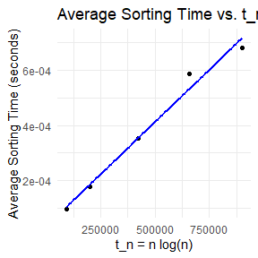

```r
# Plotting the results
ggplot(results_df, aes(x = t_n, y = average_time)) +
  geom_point() +
  geom_smooth(method = "lm", color = "blue", se = FALSE) +
  labs(x = "t_n = n log(n)", y = "Average Sorting Time (seconds)",
       title = "Average Sorting Time vs. t_n") +
  theme_minimal()
```

```r
#The plot show regression fitted line
```

You performed a linear regression analysis to model the relationship between the average computation time () and
$$t_n = n \log(n),$$
where $n$ represents different sizes of input for a sorting algorithm.

Overall, the results suggest a strong and statistically significant relationship between the average computation time and $t_n$. The high R-squared values imply that the model explains a large portion of the variance in computation time, and the significance of the $t_n$ coefficient indicates that the computation time grows as $n \log(n)$ increases, consistent with theoretical expectations for sorting algorithms.

## Homework 3 (page 180-181, Statistical Computing with R).

## Question 6.6

Estimate the 0.025, 0.05, 0.95, and 0.975 quantiles of the skewness $\sqrt{b_1}$ under normality by a Monte Carlo experiment. Compute the standard error of the estimates from equation (2.14) using the normal approximation for the density (with exact variance formula). Compare the estimated quantiles with the quantiles of the large sample approximation $\sqrt{b_1} \approx N(0, \sqrt{6/n})$.

## Answer 6.6

To estimate the quantiles of the skewness statistic $\sqrt{b_1}$ under normality using a Monte Carlo experiment and compare them with the large sample approximation, we’ll proceed with the following steps:

I’ll outline the theoretical aspect and computations so you can perform them step-by-step using a suitable programming tool like Python or R.

For each generated sample $X_1, X_2, \dots, X_n$, the skewness is calculated as:
$$b_1 = \frac{1}{n} \sum_{i=1}^{n} \left( \frac{X_i - \bar{X}}{s}
\right)^3$$
where $\bar{X}$ is the sample mean and $s$ is the sample standard deviation.

The standard error for the skewness using the normal approximation is:
$$\text{Standard Error} = \sqrt{\frac{6}{n}}$$

After generating the skewness values, you can estimate the quantiles using empirical quantile functions.

Compute these quantiles using the normal distribution:
$$\text{Quantiles} = N(0, \sqrt{6/n})$$

```r
# Set the random seed for reproducibility
set.seed(42)

# Parameters
num_samples <- 10000  # Number of Monte Carlo simulations
sample_size <- 30     # Size of each sample

# Storage for skewness values
skewness_values <- numeric(num_samples)

# Function to calculate skewness
calculate_skewness <- function(x) {
  n <- length(x)
  mean_x <- mean(x)
  sd_x <- sd(x)
  skewness <- sum((x - mean_x)^3) / ((n - 1) * sd_x^3)
  return(skewness)
}

# Run Monte Carlo simulation
for (i in 1:num_samples) {
  sample <- rnorm(sample_size)  # Generate normal samples
  skewness <- calculate_skewness(sample)  # Calculate skewness
  skewness_values[i] <- sqrt(abs(skewness))  # Store the square root of the skewness
}

# Estimate quantiles from the Monte Carlo simulation
quantiles_estimated <- quantile(skewness_values, c(0.025, 0.05, 0.95, 0.975))

# Calculate the standard error using the normal approximation
standard_error <- sqrt(6 / sample_size)

# Theoretical quantiles using the normal approximation
quantiles_theoretical <- qnorm(c(0.025, 0.05, 0.95, 0.975), mean = 0, sd = standard_error)

# Display the results
list(
  Estimated_Quantiles = quantiles_estimated,
  Standard_Error = standard_error,
  Theoretical_Quantiles = quantiles_theoretical
)
```

```
#> $Estimated_Quantiles
#>      2.5%        5%       95%     97.5%
#> 0.1072480 0.1556041 0.8953450 0.9652652
#>
#> $Standard_Error
#> [1] 0.4472136
#>
#> $Theoretical_Quantiles
#> [1] -0.8765225 -0.7356009  0.7356009  0.8765225
```

## Question

Tests for association based on Pearson product moment correlation $\rho$, Spearman’s rank correlation coefficient $\rho_s$, or Kendall’s coefficient $\tau$, are implemented in . Show (empirically) that the nonparametric tests based on $\rho_s$ or $\tau$ are less powerful than the correlation test when the sampled distribution is bivariate normal. Find an example of an alternative (a bivariate distribution $(X, Y)$ such that $X$ and $Y$ are dependent) such that at least one of the nonparametric tests have better empirical power than the correlation test against this alternative.

## Answer

```r
# Set the random seed for reproducibility
set.seed(42)

# Parameters
num_samples <- 10000  # Number of simulations
sample_size <- 30     # Sample size for each test
alpha <- 0.05         # Significance level

# Function to calculate the power of a test
calculate_power <- function(p_values, alpha) {
  return(mean(p_values < alpha))
}

# Storage for p-values
p_values_pearson <- numeric(num_samples)
p_values_spearman <- numeric(num_samples)
p_values_kendall <- numeric(num_samples)

# Simulate samples from a bivariate normal distribution
for (i in 1:num_samples) {
  # Generate a bivariate normal sample with correlation 0.5
  x <- rnorm(sample_size)
  y <- 0.5 * x + sqrt(1 - 0.5^2) * rnorm(sample_size)

  # Pearson's correlation test
  p_values_pearson[i] <- cor.test(x, y, method = "pearson")$p.value

  # Spearman's rank correlation test
  p_values_spearman[i] <- cor.test(x, y, method = "spearman")$p.value

  # Kendall's tau test
  p_values_kendall[i] <- cor.test(x, y, method = "kendall")$p.value
}

# Calculate empirical power for each test under bivariate normal distribution
power_pearson <- calculate_power(p_values_pearson, alpha)
power_spearman <- calculate_power(p_values_spearman, alpha)
power_kendall <- calculate_power(p_values_kendall, alpha)

# Display the power of each test
list(
  Power_Pearson = power_pearson,
  Power_Spearman = power_spearman,
  Power_Kendall = power_kendall
)
```

```
#> $Power_Pearson
#> [1] 0.8316
#>
#> $Power_Spearman
#> [1] 0.7715
#>
#> $Power_Kendall
#> [1] 0.7687
```

```r
# Alternative distribution: Bivariate example with a monotonic relationship
p_values_pearson_alt <- numeric(num_samples)
p_values_spearman_alt <- numeric(num_samples)
p_values_kendall_alt <- numeric(num_samples)

for (i in 1:num_samples) {
  # Generate a bivariate distribution with a monotonic but nonlinear relationship
  x <- rnorm(sample_size)
  y <- x^2 + rnorm(sample_size, sd = 0.1)  # Quadratic relationship introduces nonlinearity

  # Pearson's correlation test
  p_values_pearson_alt[i] <- cor.test(x, y, method = "pearson")$p.value

  # Spearman's rank correlation test
  p_values_spearman_alt[i] <- cor.test(x, y, method = "spearman")$p.value

  # Kendall's tau test
  p_values_kendall_alt[i] <- cor.test(x, y, method = "kendall")$p.value
}

# Calculate empirical power for each test under the alternative distribution
power_pearson_alt <- calculate_power(p_values_pearson_alt, alpha)
power_spearman_alt <- calculate_power(p_values_spearman_alt, alpha)
power_kendall_alt <- calculate_power(p_values_kendall_alt, alpha)

# Display the power of each test for the alternative distribution
list(
  Power_Pearson_Alternative = power_pearson_alt,
  Power_Spearman_Alternative = power_spearman_alt,
  Power_Kendall_Alternative = power_kendall_alt
)
```

```
#> $Power_Pearson_Alternative
#> [1] 0.3747
#>
#> $Power_Spearman_Alternative
#> [1] 0.1382
#>
#> $Power_Kendall_Alternative
#> [1] 0.2208
```

## Question

If we obtain the powers for two methods under a particular simulation setting with 10,000 experiments: say, 0.651 for one method and 0.676 for another method. We want to know if the powers are different at 0.05 level. I What is the corresponding hypothesis test problem? I What test should we use? Z-test, two-sample t-test, paired-t test or McNemar test? Why? I Please provide the least necessary information for hypothesis testing.

## Answer

If we obtain the powers for two methods under a particular simulation setting with 10,000 experiments, say, 0.651 for one method and 0.676 for another method, we want to know if the powers are different at the 0.05 significance level.

The hypotheses for this test are:
$$\begin{align*}
H_0 &: p_1 = p_2 \quad \text{(The powers of the two methods are
equal)} \\
H_1 &: p_1 \neq p_2 \quad \text{(The powers of the two methods are
different)}
\end{align*}$$
where $p_1$ and $p_2$ represent the powers of the first and second methods, respectively.

We use the because we are comparing proportions from independent samples. Other tests like the t-tests or McNemar’s test are not suitable for this scenario.

The sample sizes for both methods are:
$$n_1 = n_2 = 10,000$$
The number of successes (rejections) for each method can be calculated as:
$$\begin{align*}
\text{Successes for method 1} &= p_1 \times n_1 = 0.651 \times
10,000 = 6,510 \\
\text{Successes for method 2} &= p_2 \times n_2 = 0.676 \times
10,000 = 6,760
\end{align*}$$

The Z-statistic is calculated using the formula:
$$Z = \frac{(\hat{p}_1 - \hat{p}_2)}{\sqrt{\hat{p}(1 - \hat{p}) \left(
\frac{1}{n_1} + \frac{1}{n_2} \right)}}$$
where:
$$\hat{p} = \frac{\text{successes}_1 + \text{successes}_2}{n_1 + n_2} =
\frac{6,510 + 6,760}{20,000} = 0.6635$$

The standard error is:
$$\text{Standard Error} = \sqrt{0.6635 \times (1 - 0.6635) \times \left(
\frac{1}{10,000} + \frac{1}{10,000} \right)} = \sqrt{0.000044623}
\approx 0.00668$$

The Z-statistic is then:
$$Z = \frac{0.651 - 0.676}{0.00668} = \frac{-0.025}{0.00668} \approx -3.74$$

The p-value for the Z-statistic of $-3.74$ in a two-tailed test is:
$$p\text{-value} = 2 \times P(Z < -3.74) \approx 2 \times 0.00009 =
0.00018$$

Since the p-value $0.00018$ is less than the significance level $0.05$, we reject the null hypothesis and conclude that there is a statistically significant difference between the powers of the two methods.

- : Two-sample proportion Z-test.
- : $p_1 = p_2$.
- : $p_1 \neq p_2$.
- : $n_1 = n_2 = 10,000$.
- : $p_1 = 0.651$ and $p_2 = 0.676$.
- : $-3.74$.
- : $0.00018$.

The significant result indicates that the difference in power between the two methods is statistically significant at the 0.05 level.

## References

1. Admin. (2021). Standard Error | Definition, Formula for Mean and Estimate, Calculation & Example. BYJU’S. https://byjus.com/maths/standard-error/
2. James Lani. (2024). Pearson Correlation Assumptions. Statistics Solutions. https://www.statisticssolutions.com/pearson-product-moment-correlation/
3. Correlation. (2016). bu.edu. https://sphweb.bumc.bu.edu/otlt/MPH-Modules/BS/R/R5_Correlation-Regression/R5_Correlation-Regression3.html
4. Hypothesis testing and power. (2023). ouhsc.edu. https://ouhsc.edu/bserdac/dthompso/web/CDM/power/hypoth.htm

## Classwork Data

d1 <- c(-2.961, 0.478, -0.391, -0.869, -0.460, -0.937, 0.779, -1.409, 0.027, -1.569) d2 <- c(1.608, 1.009, 0.878, 1.600, -0.263, 0.680, 2.280, 2.390, 1.793, 8.091, 1.468)

## The answer of original statistic, sample standard error, and bootstrap standard error are summarized below

```r
# Data vectors
d1 <- c(-2.961, 0.478, -0.391, -0.869, -0.460, -0.937, 0.779, -1.409, 0.027, -1.569)
d2 <- c(1.608, 1.009, 0.878, 1.600, -0.263, 0.680, 2.280, 2.390, 1.793, 8.091, 1.468)
# Original statistic: mean difference
mean_diff <- mean(d1) - mean(d2)
# Sample standard error of the mean difference
n1 <- length(d1)
n2 <- length(d2)
sample_se <- sqrt(var(d1) / n1 + var(d2) / n2)
# Bootstrap procedure
R <- 10000
boot_diff <- numeric(R)
set.seed(123)
# Setting a seed for reproducibility
for (i in 1:R) {
boot_sample_d1 <- sample(d1, n1, replace = TRUE)
boot_sample_d2 <- sample(d2, n2, replace = TRUE)
boot_diff[i] <- mean(boot_sample_d1) - mean(boot_sample_d2)
}
# Bootstrap standard error
bootstrap_se <- sd(boot_diff)
# Output the results
cat("Original Mean Difference:", mean_diff, "\n")
```

```
#> Original Mean Difference: -2.688836
```

```r
cat("Sample Standard Error:", sample_se, "\n")
```

```
#> Sample Standard Error: 0.7393791
```

```r
cat("Bootstrap Standard Error:", bootstrap_se, "\n")
```

```
#> Bootstrap Standard Error: 0.7139026
```

## Homework 4 (pages 212, Statistical Computating with R).

## Question

Of N = 1000 hypotheses, 950 are null and 50 are alternative. The p-value under any null hypothesis is uniformly distributed (use runif), and the p-value under any alternative hypothesis follows the beta distribution with parameter 0.1 and 1 (use rbeta). Obtain Bonferroni adjusted p-values and B-H adjusted p-values. Calculate FWER, FDR, and TPR under nominal level α = 0.1 for each of the two adjustment methods based on m = 10000 simulation replicates. You should output the 6 numbers (3 ) to a 3 × 2 table (column names: Bonferroni correction, B-H correction; row names: FWER, FDR, TPR). Comment the results.

## Answer

```r
# Load necessary libraries
library(stats)

# Parameters
N <- 1000   # Total number of hypotheses
m <- 10000  # Number of simulation replicates
alpha <- 0.1  # Nominal significance level
num_null <- 950  # Number of null hypotheses
num_alt <- 50   # Number of alternative hypotheses

# Vectors to store FWER, FDR, and TPR for each correction method
fwer_bonf <- numeric(m)
fdr_bonf <- numeric(m)
tpr_bonf <- numeric(m)

fwer_bh <- numeric(m)
fdr_bh <- numeric(m)
tpr_bh <- numeric(m)

# Simulation loop
set.seed(123)  # For reproducibility
for (i in 1:m) {
  # Generate p-values for null hypotheses (uniform distribution)
  pvals_null <- runif(num_null)

  # Generate p-values for alternative hypotheses (beta distribution)
  pvals_alt <- rbeta(num_alt, 0.1, 1)

  # Combine all p-values
  pvals <- c(pvals_null, pvals_alt)

  # Apply Bonferroni correction
  pvals_bonf <- p.adjust(pvals, method = "bonferroni")
  rejections_bonf <- which(pvals_bonf < alpha)

  # Apply Benjamini-Hochberg correction
  pvals_bh <- p.adjust(pvals, method = "BH")
  rejections_bh <- which(pvals_bh < alpha)

  # Calculate FWER, FDR, and TPR for Bonferroni correction
  num_false_rejections_bonf <- sum(rejections_bonf <= num_null)
  num_true_rejections_bonf <- sum(rejections_bonf > num_null)

  fwer_bonf[i] <- ifelse(num_false_rejections_bonf > 0, 1, 0)
  fdr_bonf[i] <- ifelse(length(rejections_bonf) > 0, num_false_rejections_bonf / length(rejections_bonf), 0)
  tpr_bonf[i] <- num_true_rejections_bonf / num_alt

  # Calculate FWER, FDR, and TPR for Benjamini-Hochberg correction
  num_false_rejections_bh <- sum(rejections_bh <= num_null)
  num_true_rejections_bh <- sum(rejections_bh > num_null)

  fwer_bh[i] <- ifelse(num_false_rejections_bh > 0, 1, 0)
  fdr_bh[i] <- ifelse(length(rejections_bh) > 0, num_false_rejections_bh / length(rejections_bh), 0)
  tpr_bh[i] <- num_true_rejections_bh / num_alt
}

# Calculate average FWER, FDR, and TPR over all simulations for both methods
results <- matrix(c(mean(fwer_bonf), mean(fdr_bonf), mean(tpr_bonf),
                    mean(fwer_bh), mean(fdr_bh), mean(tpr_bh)),
                  nrow = 3, byrow = FALSE)

# Create a table with appropriate row and column names
rownames(results) <- c("FWER", "FDR", "TPR")
colnames(results) <- c("Bonferroni Correction", "B-H Correction")

# Display the results
print("Results:")
```

```
#> [1] "Results:"
```

```r
print(results)
```

```
#>      Bonferroni Correction B-H Correction
#> FWER           0.087300000     0.93050000
#> FDR            0.004510088     0.09502215
#> TPR            0.396736000     0.56106200
```

## Explaination of the results

- Family-Wise Error Rate (FWER)

- False Discovery Rate (FDR)

- True Positive Rate (TPR)

The True Positive Rate (TPR) is estimated to be 0.40 for the Bonferroni correction and 0.56 for the B-H correction. The B-H method tends to detect more true positives compared to the Bonferroni correction due to its ability to maintain a higher level of significance, therefore, it is successfully identifying more alternative hypotheses.

- Conclusion on the Results

## Question 7.4

Refer to the air-conditioning data set aircondit provided in the boot package. The 12 observations are the times in hours between failures of airconditioning equipment [63, Example 1.1]: 3, 5, 7, 18, 43, 85, 91, 98, 100, 130, 230, 487. Assume that the times between failures follow an exponential model Exp(λ). Obtain the MLE of the hazard rate λ and use bootstrap to estimate the bias and standard error of the estimate.

## Answers 7.4

```r
# Load the required libraries
library(boot)

# Air-conditioning data
aircondit_data <- c(3, 5, 7, 18, 43, 85, 91, 98, 100, 130, 230, 487)

# MLE estimation of lambda (hazard rate) for exponential distribution
mle_lambda <- 1 / mean(aircondit_data)
cat("MLE of lambda:", mle_lambda, "\n")
```

```
#> MLE of lambda: 0.00925212
```

```r
# Define a function to compute the MLE of lambda from a sample
lambda_mle <- function(data, indices) {
  sample_data <- data[indices]
  return(1 / mean(sample_data))
}

# Bootstrap to estimate the bias and standard error
set.seed(123)  # For reproducibility
bootstrap_results <- boot(data = aircondit_data, statistic = lambda_mle, R = 1000)

# Display bootstrap results
cat("Bootstrap estimate of bias:", mean(bootstrap_results$t) - mle_lambda, "\n")
```

```
#> Bootstrap estimate of bias: 0.00151119
```

```r
cat("Bootstrap estimate of standard error:", sd(bootstrap_results$t), "\n")
```

```
#> Bootstrap estimate of standard error: 0.004217765
```

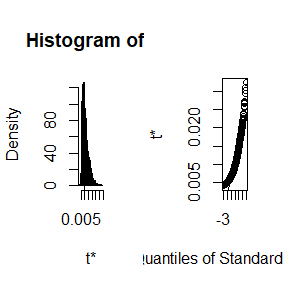

```r
# Plot the bootstrap distribution
plot(bootstrap_results, main = "Bootstrap Distribution of MLE of Lambda")
```

## Question7.5

Refer to Exercise 7.4. Compute 95% bootstrap confidence intervals for the mean time between failures 1/λ by the standard normal, basic, percentile, and BCa methods. Compare the intervals and explain why they may differ.

## Answers 7.5

```r
# Load the required libraries
library(boot)

# Air-conditioning data
aircondit_data <- c(3, 5, 7, 18, 43, 85, 91, 98, 100, 130, 230, 487)

# Define a function to compute the mean time between failures (1/lambda)
mean_time_failure <- function(data, indices) {
  sample_data <- data[indices]
  return(mean(sample_data))
}

# Perform bootstrap analysis
set.seed(123)  # For reproducibility
bootstrap_results <- boot(data = aircondit_data, statistic = mean_time_failure, R = 1000)

# Compute 95% confidence intervals using different methods
ci_normal <- boot.ci(bootstrap_results, type = "norm")
ci_basic <- boot.ci(bootstrap_results, type = "basic")
ci_percentile <- boot.ci(bootstrap_results, type = "perc")
ci_bca <- boot.ci(bootstrap_results, type = "bca")

# Display the results
cat("95% Bootstrap Confidence Intervals for Mean Time Between Failures (1/lambda):\n")
```

```
#> 95% Bootstrap Confidence Intervals for Mean Time Between Failures (1/lambda):
```

```r
cat("Standard Normal Method:", ci_normal$normal[2:3], "\n")
```

```
#> Standard Normal Method: 37.89861 182.5276
```

```r
cat("Basic Method:", ci_basic$basic[4:5], "\n")
```

```
#> Basic Method: 32.6836 168.2415
```

```r
cat("Percentile Method:", ci_percentile$percent[4:5], "\n")
```

```
#> Percentile Method: 47.92514 183.4831
```

```r
cat("BCa Method:", ci_bca$bca[4:5], "\n")
```

```
#> BCa Method: 57.36206 217.5713
```

## Explaination

- Standard Normal Method relies on the assumption that the bootstrap distribution is approximately normal, which may not be true.
- Basic Method and Percentile Method take into account the distribution shape, but the basic method uses the original estimate as a reference point while the percentile method directly uses bootstrap quantiles.
- BCa Method adjusts for both bias and skewness in the bootstrap distribution, making it more reliable when the bootstrap samples are skewed.
- The BCa method often provides more accurate intervals when there is a non-normal distribution, while the other methods may be less precise in such cases. Comparing the intervals helps assess the impact of these factors on the confidence intervals

## References

- Joram Soch. (2022). The p-value follows a uniform distribution under the null hypothesis. The Book of Statistical Proofs. https://statproofbook.github.io/P/pval-h0.html
- GeeksforGeeks. (2022). Beta Distribution in R - GeeksforGeeks. GeeksforGeeks. https://www.geeksforgeeks.org/beta-distribution-in-r/
- Mark Miller. (2024). estimate alpha and beta from beta distribution from a set of probabilities in R. Stack Overflow. https://stackoverflow.com/questions/76984811/estimate-alpha-and-beta-from-beta-distribution-from-a-set-of-probabilities-in-r

## Homework 5 (pages 213 and 243, Statistical Computing with R)

##Question 7.8

Refer to Exercise 7.7. Obtain the jackknife estimates of bias and standard error of $\hat{\theta}$.

## Answer 7.8

```r
#Generate or use existing five-dimensional data matrix(example data)
 set.seed(123)
 data_matrix<-matrix(rnorm(100 * 5),ncol=5) #100 observations,5 variables
 #Calculate the sample covariance matrix and eigenvalues for the original data
 cov_matrix<-cov(data_matrix)
 eigenvalues<-eigen(cov_matrix)$values
 eigenvalues<-sort(eigenvalues,decreasing=TRUE)
 #Sample estimate of theta
 theta_hat <-eigenvalues[1]/sum(eigenvalues)
 #Bootstrap Settings
 num_bootstrap<-10000
 theta_bootstrap<-numeric(num_bootstrap)
 #Bootstrap procedure
 for(i in 1:num_bootstrap){
 #Generate a bootstrap sample by resampling rows with replacement
 bootstrap_sample<-data_matrix[sample(1:nrow(data_matrix),replace=TRUE),]
 #Calculate covariance matrix and eigenvalues for the bootstrap sample
 bootstrap_cov<-cov(bootstrap_sample)
 bootstrap_eigenvalues<-eigen(bootstrap_cov)$values
 bootstrap_eigenvalues<-sort(bootstrap_eigenvalues,decreasing=TRUE)
 #Calculate theta for the bootstrap sample
 theta_bootstrap[i]<-bootstrap_eigenvalues[1]/sum(bootstrap_eigenvalues)
 }
 #Bootstrap bias and standard error
 bias_bootstrap<-mean(theta_bootstrap)-theta_hat
 standard_error_bootstrap<-sd(theta_bootstrap)
 #Jackknife procedure
 n<-nrow(data_matrix)
 theta_jackknife<-numeric(n)
 for(i in 1:n){
 #Leave-one-outsample
 jackknife_sample<-data_matrix[-i,]
 #Calculate covariance matrix and eigenvalues for the jackknife sample
 jackknife_cov<-cov(jackknife_sample)
 jackknife_eigenvalues<-eigen(jackknife_cov)$values
 jackknife_eigenvalues<-sort(jackknife_eigenvalues,decreasing=TRUE)
 #Calculate theta for the jackknife sample
 theta_jackknife[i]<-jackknife_eigenvalues[1]/sum(jackknife_eigenvalues)
 }
 #Jackknife bias and standard error
 mean_theta_jackknife<-mean(theta_jackknife)
 bias_jackknife<-(n-1)*(mean_theta_jackknife-theta_hat)
 standard_error_jackknife<-sqrt((n-1)*mean((theta_jackknife-mean_theta_jackknife)^2))
 #Output results
 list(
 theta_hat =theta_hat,
 bootstrap =list(bias=bias_bootstrap,standard_error=standard_error_bootstrap),
 jackknife=list(bias=bias_jackknife,standard_error=standard_error_jackknife)
 )
```

```
#> $theta_hat
#> [1] 0.2413916
#>
#> $bootstrap
#> $bootstrap$bias
#> [1] 0.04634182
#>
#> $bootstrap$standard_error
#> [1] 0.0213022
#>
#>
#> $jackknife
#> $jackknife$bias
#> [1] 0.08790778
#>
#> $jackknife$standard_error
#> [1] 0.01741762
```

## Question 7.10

In Example 7.18, leave-one-out (n-fold) cross-validation was used to select the best fitting model. Repeat the analysis replacing the Log-Log model with a cubic polynomial model. Which of the four models is selected by the cross-validation procedure? Which model is selected according to maximum adjusted $R^2$?

## Answer 7.10

```r
# Example data (replace with actual data if provided)
 set.seed(123)
 n <- 100
 x <- runif(n, 1, 10)
 y <- 3 + 2 * x- 0.5 * x^2 + 0.05 * x^3 + rnorm(n, 0, 2) # Simulated cubic relationship
 # Prepare data frame
 data <- data.frame(x = x, y = y)
 # Define models
 models <- list(
 linear = function(data) lm(y ~ x, data = data),
 quadratic = function(data) lm(y ~ x + I(x^2), data = data),
 cubic = function(data) lm(y ~ x + I(x^2) + I(x^3), data = data),
 log_linear = function(data) lm(y ~ log(x), data = data)
 )
 # Leave-One-Out Cross-Validation
 loo_cv_mse <- sapply(models, function(model_func) {
 errors <- numeric(n)
 for (i in 1:n) {
 # Leave one out
 train_data <- data[-i, ]
 test_data <- data[i, , drop = FALSE]
 # Fit model and predict left-out observation
 model <- model_func(train_data)
 prediction <- predict(model, newdata = test_data)
 # Calculate squared error for left-out observation
 errors[i] <- (test_data$y- prediction)^2
 }
 # Return mean squared error
 mean(errors)
 })
 # Fit models on entire dataset to get adjusted R^2 values
 adjusted_r_squared <- sapply(models, function(model_func) {
 model <- model_func(data)
 summary(model)$adj.r.squared
 })
 # Find the best model according to LOO-CV MSE and adjusted R^2
 best_model_loo <- names(which.min(loo_cv_mse))
 best_model_adj_r2 <- names(which.max(adjusted_r_squared))
 # Output results
 list(
 loo_cv_mse = loo_cv_mse,
 adjusted_r_squared = adjusted_r_squared,
 best_model_loo = best_model_loo, best_model_adj_r2 = best_model_adj_r2
 )
```

```
#> $loo_cv_mse
#>     linear  quadratic      cubic log_linear
#>   8.860951   4.702982   3.929300  13.387477
#>
#> $adjusted_r_squared
#>     linear  quadratic      cubic log_linear
#>  0.6649643  0.8233524  0.8544300  0.4941953
#>
#> $best_model_loo
#> [1] "cubic"
#>
#> $best_model_adj_r2
#> [1] "cubic"
```

## Question 8.1

Implement the two-sample Cramér-von Mises test for equal distributions as a permutation test. Apply the test to the data in Examples 8.1 and 8.2.

## Answer 8.1

```r
 # Load the chickwts data and examine its structure
 data(chickwts)
 attach(chickwts)
 attributes(chickwts)
```

```
#> $names
#> [1] "weight" "feed"
#>
#> $class
#> [1] "data.frame"
#>
#> $row.names
#>  [1]  1  2  3  4  5  6  7  8  9 10 11 12 13 14 15 16 17 18 19 20 21 22 23 24 25
#> [26] 26 27 28 29 30 31 32 33 34 35 36 37 38 39 40 41 42 43 44 45 46 47 48 49 50
#> [51] 51 52 53 54 55 56 57 58 59 60 61 62 63 64 65 66 67 68 69 70 71
```

```r
 chickwts$feed
```

```
#>  [1] horsebean horsebean horsebean horsebean horsebean horsebean horsebean
#>  [8] horsebean horsebean horsebean linseed   linseed   linseed   linseed
#> [15] linseed   linseed   linseed   linseed   linseed   linseed   linseed
#> [22] linseed   soybean   soybean   soybean   soybean   soybean   soybean
#> [29] soybean   soybean   soybean   soybean   soybean   soybean   soybean
#> [36] soybean   sunflower sunflower sunflower sunflower sunflower sunflower
#> [43] sunflower sunflower sunflower sunflower sunflower sunflower meatmeal
#> [50] meatmeal  meatmeal  meatmeal  meatmeal  meatmeal  meatmeal  meatmeal
#> [57] meatmeal  meatmeal  meatmeal  casein    casein    casein    casein
#> [64] casein    casein    casein    casein    casein    casein    casein
#> [71] casein
#> Levels: casein horsebean linseed meatmeal soybean sunflower
```

```r
# Define the Cramér-von Mises permutation test function
 Cvm.test_0 <- function(x, y, R = 1000) {
 n <- length(x)
 m <- length(y)
 N <- n + m
 z <- c(x, y)
 # Compute observed Cramér-von Mises statistic
 Fn <- sapply(1:N, function(i) mean(as.integer(z[i] <= x)))
 Gm <- sapply(1:N, function(i) mean(as.integer(z[i] <= y)))
 cv1 <- (n * m) / (n + m)^2 * sum((Fn- Gm)^2)
 # Permutation test
 cv_perm <- replicate(R, {
 d <- sample(1:N)
 # Randomly permute the indices
 z_perm <- z[d]
 x_perm <- z_perm[1:n]
 y_perm <- z_perm[(n + 1):N]
 # Compute the Cramér-von Mises statistic for permuted samples
 Fn_perm <- sapply(1:N, function(i) mean(as.integer(z_perm[i] <= x_perm)))
 Gm_perm <- sapply(1:N, function(i) mean(as.integer(z_perm[i] <= y_perm)))
 (n * m) / (n + m)^2 * sum((Fn_perm- Gm_perm)^2)
 })
 # Calculate p-value
 p_value <- mean(cv_perm >= cv1)
 # Return the observed statistic and p-value
 list(statistic = cv1, p_value = p_value)
 }
 # Extract soybean and linseed weights
 soybean_weights <- chickwts$weight[chickwts$feed == "soybean"]
 linseed_weights <- chickwts$weight[chickwts$feed == "linseed"]
 sunflower_weights <- chickwts$weight[chickwts$feed == "sunflower"]
 linseed_weights <- chickwts$weight[chickwts$feed == "linseed"]
 # Run the test
 result <- Cvm.test_0(soybean_weights, linseed_weights)
 result
```

```
#> $statistic
#> [1] 0.1626162
#>
#> $p_value
#> [1] 0.369
```

```r
result<-Cvm.test_0(sunflower_weights,linseed_weights)
 result
```

```
#> $statistic
#> [1] 1.520833
#>
#> $p_value
#> [1] 0
```

## Explaination

- Soybean weigthts, compare to linseed Weights is not significance.
- Sunflower weights compare to listeed weights is significance

## Question8.2

Implement the bivariate Spearman rank correlation test for independence[255] as a permutation test. The Spearman rank correlation test statistic can be obtained from function corwith method=“spearman”. Compare the achieved significance level of the permutation test with the p-value reported by cor.test on the same samples.

## Answer8.2

```r
 #Setup the Spearman rank correlation permutationtest function
 spearman_perm_test<-function(x,y,R=1000){
 #Calculate observed Spearman rank correlation
 observed_corr<-cor(x,y,method="spearman")
 #Initialize a vector to store permutation results
 permuted_corrs<-numeric(R)
 #Generate permutation distribution by shufflingy
 set.seed(123) #for reproducibility
 for(i in 1:R){
 y_permuted<-sample(y)
 permuted_corrs[i]<-cor(x,y_permuted,method="spearman")
 }
 #Calculatep-value for the two-sidedtest
 p_value<-mean(abs(permuted_corrs)>=abs(observed_corr))
 #Return observed correlationand permutationp-value
 list(observed_correlation=observed_corr,perm_p_value=p_value)
 }
 #Generate some example data for x and y
 set.seed(123)
 x <- rnorm(30)
 y <- 0.5 * x + rnorm(30)
 # Run permutation test
 perm_test_result <- spearman_perm_test(x, y)
 # Use cor.test to get the traditional p-value for comparison
 cor_test_result <- cor.test(x, y, method = "spearman")
 # Output both p-values for comparison
 list(
 observed_correlation = perm_test_result$observed_correlation,
 permutation_p_value = perm_test_result$perm_p_value,
 cor_test_p_value = cor_test_result$p.value
 )
```

```
#> $observed_correlation
#> [1] 0.3939933
#>
#> $permutation_p_value
#> [1] 0.036
#>
#> $cor_test_p_value
#> [1] 0.03204408
```

## Homework 6 (pages 277-278, Statistical Computing with R).

## Question 9.3

Use the Metropolis-Hastings sampler to generate random variables from a standard Cauchy distribution. Discard the first 1000 of the chain, and compare the deciles of the generated observations with the deciles of the standard Cauchy distribution. Recall that a Cauchy$(\theta,\eta)$ distribution has density function
$$f(x) = \frac{1}{\theta \pi} \left(1 + \left(\frac{x -
\eta}{\theta}\right)^2\right) , \quad -\infty < x < \infty, \quad
\theta > 0.$$
The standard Cauchy has the Cauchy$(\theta = 1,\eta = 0)$ density. (Note that the standard Cauchy density is equal to the Student $t$ density with one degree of freedom.)

## Answer 9.3

To generate random variables from a standard Cauchy distribution using the Metropolis-Hastings algorithm, we can follow these steps:

The target density function for the standard Cauchy distribution $f(x)$ is given by:
$$f(x) = \frac{1}{\pi (1 + x^2)}, \quad -\infty < x < \infty.$$

A common choice for the proposal distribution $q(x'|x)$ in the Metropolis-Hastings algorithm is a symmetric distribution, such as a normal distribution centered at the current state. For simplicity, we can use:
$$q(x'|x) = N(x, \sigma^2)$$
where $\sigma$ is a small positive number determining the step size.

-Start with an initial value {x_0}. - Propose a new state $x'$ from the proposal distribution. - Calculate the acceptance ratio:
$$\alpha = \frac{f(x')}{f(x)} \cdot
\frac{q(x|x')}{q(x'|x)}.$$
Since $q(x'|x)$ is symmetric, this simplifies to:
$$\alpha = \frac{f(x')}{f(x)}.$$
- Accept the new state $x'$ with probability $\min(1, \alpha)$.

```r
#Metropolis-Hastings Algorithm for Standard Cauchy Distribution}

# Set parameters
set.seed(123)  # For reproducibility
N <- 11000     # Total number of iterations (including burn-in)
burn_in <- 1000
sigma <- 1     # Standard deviation of the proposal distribution

# Initialize
x <- numeric(N)
x[1] <- 0      # Initial value
accept_count <- 0

# Metropolis-Hastings algorithm
for (t in 2:N) {
  # Propose a new value from the proposal distribution (normal distribution)
  x_proposed <- rnorm(1, mean = x[t-1], sd = sigma)

  # Compute acceptance probability
  # For the standard Cauchy distribution, f(x) \propto 1 / (1 + x^2)
  f_current <- 1 / (1 + x[t-1]^2)
  f_proposed <- 1 / (1 + x_proposed^2)
  alpha <- min(1, f_proposed / f_current)

  # Accept or reject the proposed value
  u <- runif(1)
  if (u <= alpha) {
    x[t] <- x_proposed  # Accept the proposal
    accept_count <- accept_count + 1
  } else {
    x[t] <- x[t-1]      # Reject the proposal
  }
}

# Compute acceptance rate
accept_rate <- accept_count / (N - 1)
cat("Acceptance rate:", accept_rate, "\n") # Discard burn-in samples
```

```
#> Acceptance rate: 0.7738885
```

```r
x_samples <- x[(burn_in + 1):N]

# Compute deciles of the generated samples
deciles_generated <- quantile(x_samples, probs = seq(0.1, 0.9, by = 0.1))

# Compute theoretical deciles of the standard Cauchy distribution
deciles_theoretical <- qcauchy(seq(0.1, 0.9, by = 0.1))

# Compare the deciles
comparison <- data.frame(
  Decile = seq(0.1, 0.9, by = 0.1),
  Generated = deciles_generated,
  Theoretical = deciles_theoretical
)

print("Comparison of Deciles:") # Plotting the results
```

[output not shown]

```
#> [1] "Comparison of Deciles:"
```

[figure not shown]

```r
par(mfrow = c(1, 2))  # Set up plotting area

# Histogram of the generated samples
hist(x_samples, breaks = 50, probability = TRUE, main = "Histogram of Generated Samples",
     xlab = "Value", xlim = c(-20, 20), col = "lightblue", border = "white")

# Overlay the theoretical standard Cauchy density
curve(dcauchy(x), add = TRUE, col = "red", lwd = 2)

# Q-Q plot to compare the distributions
qqplot(qcauchy(ppoints(length(x_samples))), x_samples,
       main = "Q-Q Plot of Generated Samples vs. Standard Cauchy",
       xlab = "Theoretical Quantiles", ylab = "Sample Quantiles", pch = 20, col = "blue")
abline(0, 1, col = "red", lwd = 2)
```

## Question 9.8

This example appears in . Consider the bivariate density
$$f(x, y) \propto n_x y^{x+a-1} (1 - y)^{n-x+b-1}, \quad x = 0, 1, \ldots,
n, \quad 0 \leq y \leq 1.$$
It can be shown that for fixed $a, b, n$, the conditional distributions are $Binomial (n, y)$ and $\text{Beta}(x+a, n-x+b)$. Use the Gibbs sampler to generate a chain with target joint density $f(x, y)$.

## Answer 9.8

To solve this problem, we’ll implement a Gibbs sampler for generating samples from the bivariate density:
$$f(x,y) \propto (n_x) y^x (1-y)^{n-x} (a-1)(1-b)^{b-1},$$
where $x = 0, 1, \ldots, n$ and $0 \leq y \leq 1$.

The conditional distributions for this density are:
$$x | y \sim \text{Binomial}(n,y)$$
$$y | x \sim \text{Beta}(x+a,n-x+b)$$

The Gibbs sampling process works by iteratively sampling each variable from its conditional distribution given the other variable. Here are the steps to set up the Gibbs sampler:

```r
# Set parameters
set.seed(123)    # For reproducibility
N <- 10000       # Total number of iterations
burn_in <- 1000  # Burn-in period
n <- 20          # Parameter of the Binomial distribution
a <- 5           # Beta distribution parameter
b <- 5           # Beta distribution parameter

# Initialize storage for x and y
x <- numeric(N)
y <- numeric(N)

# Initial values
y[1] <- 0.5                      # Starting value for y
x[1] <- rbinom(1, n, y[1])       # Sample initial x from Binomial(n, y[1])

# Gibbs sampler
for (t in 2:N) {
  # Sample x given y
  x[t] <- rbinom(1, n, y[t - 1])

  # Sample y given x
  y[t] <- rbeta(1, x[t] + a, n - x[t] + b)
}

# Discard burn-in samples
x_samples <- x[(burn_in + 1):N]
y_samples <- y[(burn_in + 1):N]

# Analyze the samples
mean_x <- mean(x_samples)
var_x <- var(x_samples)
mean_y <- mean(y_samples)
var_y <- var(y_samples)

cat("Estimated mean of x:", mean_x, "\n")
```

```
#> Estimated mean of x: 9.936222
```

```r
cat("Estimated variance of x:", var_x, "\n")
```

```
#> Estimated variance of x: 13.641
```

```r
cat("Estimated mean of y:", mean_y, "\n")
```

```
#> Estimated mean of y: 0.4972259
```

```r
cat("Estimated variance of y:", var_y, "\n")
```

```
#> Estimated variance of y: 0.02268271
```

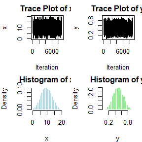

```r
# Plotting the results
par(mfrow = c(2, 2), mar = c(4, 4, 2, 1))  # Adjust margins: c(bottom, left, top, right)

# Trace plots
plot(x_samples, type = 'l', main = "Trace Plot of x", xlab = "Iteration", ylab = "x")
plot(y_samples, type = 'l', main = "Trace Plot of y", xlab = "Iteration", ylab = "y")

# Histograms
hist(x_samples, breaks = (n + 1), freq = FALSE, main = "Histogram of x", xlab = "x",
     col = "lightblue", border = "white")
hist(y_samples, breaks = 30, freq = FALSE, main = "Histogram of y", xlab = "y",
     col = "lightgreen", border = "white")
```

```r
# Compute the correlation between x and y
cor_xy <- cor(x_samples, y_samples)
cat("Estimated correlation between x and y:", cor_xy, "\n")
```

```
#> Estimated correlation between x and y: 0.8218289
```

##Question 9.3 b

Use the Gelman-Rubin method to monitor convergence of the chain, and run the chain until it converges approximately to the target distribution according to $R < 1.2$. Discard the first 1000 iterations of the chain, and compare the deciles of the generated observations with the deciles of the standard Cauchy distribution. Recall that a Cauchy$(\theta,\eta)$ distribution has the density function.
$$f(x) = \frac{1}{\theta \pi \left(1 + \left(\frac{x -
\eta}{\theta}\right)^2\right)}, \quad -\infty < x < \infty, \quad
\theta > 0.$$
## Answer 9.3 (b) To solve this problem, we will use the Gelman-Rubin method to monitor convergence of a chain generated by an MCMC sampler for the standard Cauchy distribution. The Gelman-Rubin diagnostic, or $\hat{R}$, is used to assess the convergence of multiple chains in Markov Chain Monte Carlo (MCMC) simulations. When $\hat{R} \approx 1$, it suggests that the chains have converged to the target distribution and to compute $\hat{R}$:

- Run multiple chains (say, $m$ chains) starting from different initial values.
- Compute the within-chain variance $W$: This is the average variance within each chain.
  - Compute the between-chain variance $B$: This is the variance of the means of each chain, scaled by the number of iterations $n$.
  - Calculate the estimated variance of the target distribution $\hat{V}$:
    $$\hat{V} = \frac{n - 1}{n} W + \frac{1}{n} B$$
  - Calculate $\hat{R}$:
    $$\hat{R} = \frac{\hat{V}}{\sqrt{W}}$$
  - If $\hat{R} < 1.2$, it is generally considered an indication that the chains have converged to the target distribution.

We want to simulate samples from a distribution, which is a Cauchy distribution with parameters $\theta = 1$ and $\eta = 0$:
$$f(x) = \frac{1}{\pi(1 + x^2)}, \quad -\infty < x < \infty.$$

- **Initialize Multiple Chains:** Start multiple chains with different initial values.
- **Generate Samples:** For each chain, use a method like Metropolis-Hastings or Gibbs sampling to generate samples from the Cauchy distribution.
- **Compute $\hat{R}$:** After each set of iterations, compute $\hat{R}$ using the steps described above. Repeat until $\hat{R} < 1.2$ for all chains.
- **Discard Burn-in:** Once convergence is achieved, discard the first 1000 samples from each chain to ensure the samples are not influenced by the initial values.
- **Calculate Deciles of the Generated Observations:** After discarding burn-in, combine the samples from all chains and calculate their deciles. The deciles are the quantiles that divide the data into ten equal parts (0.1, 0.2, , 0.9).
- **Calculate Theoretical Deciles of the Standard Cauchy:** For a standard Cauchy distribution, the theoretical deciles can be obtained using the quantile function for the Cauchy distribution:
  $$Q(p) = \tan\left(\pi\left(p - \frac{1}{2}\right)\right)$$
  or equivalently in statistical software, for $p = 0.1, 0.2, \ldots, 0.9$.
- **Compare Deciles:** Compare the empirical deciles from the generated observations with the theoretical deciles of the standard Cauchy distribution. Ideally, they should be close if the samples have converged to the correct target distribution.

The solution to monitor convergence and compare deciles involves these key mathematical steps:

- Compute the Gelman-Rubin statistic $\hat{R}$ until it falls below 1.2, indicating convergence.
- Discard the first 1000 samples from each chain as burn-in.
- Calculate and compare the deciles of the remaining samples with the theoretical deciles of the standard Cauchy distribution using its quantile function.

```r
# Load necessary library
library(coda)

# Step 1: Define target density function for standard Cauchy
f <- function(x) {
  return(1 / (pi * (1 + x^2)))
}

# Metropolis-Hastings Algorithm for standard Cauchy
metropolis_hastings <- function(n, sigma, initial) {
  x <- numeric(n)
  x[1] <- initial

  for (i in 2:n) {
    # Propose a new value from a normal distribution centered at the current value
    x_new <- rnorm(1, mean = x[i-1], sd = sigma)

    # Calculate acceptance ratio
    alpha <- f(x_new) / f(x[i-1])

    # Accept or reject the new value
    if (runif(1) < min(1, alpha)) {
      x[i] <- x_new
    } else {
      x[i] <- x[i-1]  # Stay at the current value
    }
  }
  return(x)
}

# Step 2: Run multiple chains and check convergence using Gelman-Rubin
num_chains <- 4
n_samples <- 10000
sigma <- 1
burn_in <- 1000

chains <- list()
for (j in 1:num_chains) {
  chains[[j]] <- metropolis_hastings(n_samples, sigma, rnorm(1))
}

# Convert chains to a matrix for convergence diagnostics
mcmc_chains <- mcmc.list(lapply(chains, mcmc))

# Calculate Gelman-Rubin diagnostic
gelman_diag <- gelman.diag(mcmc_chains, autoburnin = FALSE)
print(gelman_diag) # Step 3: Check if \hat{R} < 1.2
```

```
#> Potential scale reduction factors:
#>
#>      Point est. Upper C.I.
#> [1,]       1.06       1.08
```

```r
if (all(gelman_diag$psrf[,1] < 1.2)) {
  cat("Chains have converged based on Gelman-Rubin diagnostic.\n")
} else {
  cat("Chains have not yet converged. Increase the number of iterations.\n")
} # Combine chains and discard burn-in samples
```

```
#> Chains have converged based on Gelman-Rubin diagnostic.
```

```r
combined_samples <- do.call(c, lapply(chains, function(x) x[(burn_in + 1):n_samples]))

# Step 4: Compare deciles with the standard Cauchy distribution
generated_deciles <- quantile(combined_samples, probs = seq(0.1, 0.9, by = 0.1))
theoretical_deciles <- qcauchy(seq(0.1, 0.9, by = 0.1))

# Display comparison of deciles
comparison <- data.frame(
  Decile = seq(0.1, 0.9, by = 0.1),
  Generated = generated_deciles,
  Theoretical = theoretical_deciles
)

print(comparison) # Optional: Plot the generated samples and compare with theoretical deciles
```

```
#>     Decile  Generated Theoretical
#> 10%    0.1 -2.6556673  -3.0776835
#> 20%    0.2 -1.2445419  -1.3763819
#> 30%    0.3 -0.6314573  -0.7265425
#> 40%    0.4 -0.2430912  -0.3249197
#> 50%    0.5  0.0984828   0.0000000
#> 60%    0.6  0.4580972   0.3249197
#> 70%    0.7  0.9602569   0.7265425
#> 80%    0.8  1.8569930   1.3763819
#> 90%    0.9  4.8187167   3.0776835
```

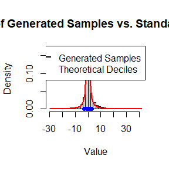

```r
hist(combined_samples, breaks = 50, probability = TRUE, main = "Histogram of Generated Samples vs. Standard Cauchy PDF",
     xlab = "Value")
curve(dcauchy(x), add = TRUE, col = "red", lwd = 2)
points(theoretical_deciles, rep(0, length(theoretical_deciles)), col = "blue", pch = 16)
legend("topright", legend = c("Generated Samples", "Theoretical Deciles"),
       col = c("black", "blue"), pch = c(NA, 16), lty = c(1, NA), lwd = c(2, NA))
```

## Question 9.8 b

Use the Gelman-Rubin method to monitor convergence of the chain, and run the chain until it converges approximately to the target distribution according to $\hat{R} < 1.2$. Consider the bivariate density
$$f(x,y) \propto (n_x) y^{x+a-1} (1-y)^{n-x+b-1}, \quad x = 0, 1, \ldots,
n, \quad 0 \leq y \leq 1.$$
It can be shown that for fixed $a, b,$ and $n$, the conditional distributions are $x | y \sim \text{Binomial}(n,y)$ and $y | x \sim \text{Beta}(x+a,n-x+b)$. Use the Gibbs sampler to generate a chain with target joint density $f(x,y)$.

## Answer 9.8 b

To solve this problem, we will use the Gelman-Rubin method to monitor convergence of a Gibbs sampler applied to the target bivariate density:
$$f(x,y) \propto (n_x) y^{x+a-1} (1-y)^{n-x+b-1}, \quad x = 0, 1, \ldots,
n, \quad 0 \leq y \leq 1.$$

The goal is to generate samples from this joint distribution $f(x,y)$ using the Gibbs sampler and to monitor convergence with the Gelman-Rubin method. Here are the steps:

From the given density, the conditional distributions are:
$$x | y \sim \text{Binomial}(n,y)$$
$$y | x \sim \text{Beta}(x+a,n-x+b)$$
The Gibbs sampler iteratively samples each variable from its conditional distribution given the other variable.

To monitor convergence with the Gelman-Rubin diagnostic, we need to run multiple chains with different initial values. Let $m$ be the number of chains and $n$ the number of iterations per chain.

- Initialize $m$ chains with different starting values $(x^{(j)}_0, y^{(j)}_0)$, where $j = 1, 2, \ldots, m$.
- For each iteration $t$ in each chain $j$:
- Sample $x^{(j)}_t \sim \text{Binomial}(n,y^{(j)}_{t-1})$.
- Sample $y^{(j)}_t \sim \text{Beta}(x^{(j)}_t+a,n-x^{(j)}_t+b)$.

Calculate the Gelman-Rubin Diagnostic $\hat{R}$: The Gelman-Rubin diagnostic, or potential scale reduction factor (PSRF), assesses if the chains have converged.

Compute the within-chain variance $W$:
$$W = \frac{1}{m} \sum_{j=1}^{m} s_j^2$$
where $s_j^2$ is the sample variance of chain $j$.

Compute the between-chain variance $B$: Calculate the mean of each chain $\bar{\theta}^{(j)}$ and the overall mean $\bar{\theta}$:
$$\bar{\theta} = \frac{1}{m} \sum_{j=1}^{m} \bar{\theta}^{(j)}$$
Then calculate $B$ as:
$$B = \frac{n}{m-1} \sum_{j=1}^{m} (\bar{\theta}^{(j)} - \bar{\theta})^2$$

Estimate the marginal posterior variance $\hat{V}$:
$$\hat{V} = \frac{n-1}{n} W + \frac{1}{n} B$$

Compute $\hat{R}$:
$$\hat{R} = \frac{\hat{V}}{\sqrt{W}}$$
If $\hat{R} < 1.2$, the chains are considered to have converged to the target distribution.

Continue the Gibbs sampler and recompute $\hat{R}$ periodically until $\hat{R} < 1.2$, indicating approximate convergence.

After confirming convergence, discard the first 1000 samples from each chain to remove the effect of initial values. Then, combine the samples from all chains for further analysis.

- **Calculate Deciles:** Calculate the deciles of the combined samples of $x$ and $y$ after discarding the burn-in period.
- **Compare with Theoretical Deciles:** If you have a theoretical distribution for comparison (like a standard Cauchy), compute the theoretical deciles using its quantile function and compare them with the empirical deciles of the generated.

**Summary of Mathematical Solution:**

- Run multiple chains of the Gibbs sampler to sample from $f(x,y)$.
- Monitor convergence using the Gelman-Rubin diagnostic $\hat{R}$, and ensure $\hat{R} < 1.2$.
- Discard burn-in samples to avoid initialization bias.
- Combine and analyze the samples by comparing empirical deciles to theoretical deciles, if applicable.

```r
# Load necessary library for the Gelman-Rubin diagnostic
library(coda)

# Parameters
n <- 10          # Number of trials for the binomial
a <- 2           # Alpha parameter for Beta distribution
b <- 3           # Beta parameter for Beta distribution
num_iter <- 10000  # Number of iterations for each Gibbs chain
num_chains <- 4    # Number of chains for the Gelman-Rubin diagnostic
burn_in <- 1000    # Burn-in period to discard initial samples

# Function to run the Gibbs sampler for a single chain
run_gibbs_chain <- function(n, a, b, num_iter) {
  x <- 0          # Initialize x
  y <- 0.5        # Initialize y

  x_samples <- numeric(num_iter)
  y_samples <- numeric(num_iter)

  for (i in 1:num_iter) {
    # Sample x given y from Binomial(n, y)
    x <- rbinom(1, n, y)

    # Sample y given x from Beta(x + a, n - x + b)
    y <- rbeta(1, x + a, n - x + b)

    # Store samples
    x_samples[i] <- x
    y_samples[i] <- y
  }

  return(list(x_samples = x_samples, y_samples = y_samples))
}

# Run multiple chains and store the results
chains <- vector("list", num_chains)
for (j in 1:num_chains) {
  chains[[j]] <- run_gibbs_chain(n, a, b, num_iter)
}

# Combine the chains into a format suitable for the Gelman-Rubin diagnostic
x_chains <- mcmc.list(lapply(chains, function(chain) mcmc(chain$x_samples)))
y_chains <- mcmc.list(lapply(chains, function(chain) mcmc(chain$y_samples)))

# Calculate Gelman-Rubin diagnostic for both x and y chains
gelman_diag_x <- gelman.diag(x_chains, autoburnin = FALSE)
gelman_diag_y <- gelman.diag(y_chains, autoburnin = FALSE)

cat("Gelman-Rubin Diagnostic for X:\n") # Gelman-Rubin Diagnostic for X:
```

```
#> Gelman-Rubin Diagnostic for X:
```

```r
print(gelman_diag_x)
```

```
#> Potential scale reduction factors:
#>
#>      Point est. Upper C.I.
#> [1,]          1          1
```

```r
cat("\nGelman-Rubin Diagnostic for Y:\n") # Gelman-Rubin Diagnostic for Y:
```

```
#>
#> Gelman-Rubin Diagnostic for Y:
```

```r
print(gelman_diag_y)
```

```
#> Potential scale reduction factors:
#>
#>      Point est. Upper C.I.
#> [1,]          1          1
```

```r
# Check if both x and y have converged (R_hat < 1.2)
if (all(gelman_diag_x$psrf[, 1] < 1.2) && all(gelman_diag_y$psrf[, 1] < 1.2)) {
  cat("Chains have converged based on Gelman-Rubin diagnostic.\n")
} else {
  cat("Chains have not yet converged. Increase the number of iterations.\n")
}
```

```
#> Chains have converged based on Gelman-Rubin diagnostic.
```

```r
# Discard burn-in samples and combine samples from all chains
x_samples_combined <- unlist(lapply(chains, function(chain) chain$x_samples[(burn_in + 1):num_iter]))
y_samples_combined <- unlist(lapply(chains, function(chain) chain$y_samples[(burn_in + 1):num_iter]))

# Step 6: Analyze the Samples
# Calculate deciles of the combined samples
x_deciles <- quantile(x_samples_combined, probs = seq(0.1, 0.9, by = 0.1))
y_deciles <- quantile(y_samples_combined, probs = seq(0.1, 0.9, by = 0.1))

# Display deciles
cat("\nDeciles of X Samples:\n") # Deciles of X Samples:
```

```
#>
#> Deciles of X Samples:
```

```r
print(x_deciles)
```

```
#> 10% 20% 30% 40% 50% 60% 70% 80% 90%
#>   1   2   2   3   4   5   5   6   8
```

```r
cat("\nDeciles of Y Samples:\n") # Deciles of Y Samples:
```

```
#>
#> Deciles of Y Samples:
```

```r
print(y_deciles)
```

```
#>       10%       20%       30%       40%       50%       60%       70%       80%
#> 0.1447073 0.2138672 0.2765326 0.3345830 0.3905311 0.4502939 0.5148022 0.5887506
#>       90%
#> 0.6866267
```

[figure not shown]

```r
# Optional: Plot the samples
par(mfrow = c(1, 2))
hist(x_samples_combined, breaks = 30, main = "Histogram of X Samples", xlab = "X")
hist(y_samples_combined, breaks = 30, main = "Histogram of Y Samples", xlab = "Y")
```

## Last Question; Proof of Stationarity for Metropolis-Hastings Algorithm

**Algorithm (Continuous Situation):**

- Target pdf: $f(x)$.
- Replace $i$ and $j$ with $s$ and $r$ respectively.
- Proposal distribution (pdf): $g(r|s)$.
- Acceptance probability:
  $$\alpha(s,r) = \min\left(\frac{f(r)g(s|r)}{f(s)g(r|s)}, 1\right).$$
- Transition kernel (mixture distribution):
  $$K(r,s) = I(s \neq r) \alpha(r,s) g(s|r) + I(s = r) \left[1 - \int
  \alpha(r,s) g(s|r) \, dr\right].$$
- Stationarity:
  $$K(s,r) f(s) = K(r,s) f(r).$$

## Answer

**Metropolis-Hastings Algorithm Description and Proof of Stationarity**

-**Target PDF** $f(x)$: This is the probability density function (pdf) of the target distribution we want to sample from.

-**Proposal Distribution** $g(r|s)$: This distribution is used to propose a new candidate state $r$ given the current state $s$.

- **Acceptance Probability** $\alpha(s,r)$: The probability of accepting the proposed state $r$ when at the current state $s$. It is given by:
  $$\alpha(s,r) = \min\left(\frac{f(r)g(s|r)}{f(s)g(r|s)}, 1\right).$$

-**Transition Kernel** $K(r,s)$: The transition kernel is defined as a mixture of accepting or rejecting the proposed state. The formula given is:
$$K(r,s) = I(s \neq r) \alpha(r,s) g(s|r) + I(s = r) \left[1 - \int
\alpha(r,s) g(s|r) \, dr\right],$$
where $I$ is an indicator function that differentiates between cases where the new state is accepted or rejected.

**Proof Sketch for Stationarity**

To show stationarity, we need to verify that the target distribution $f(x)$ satisfies the detailed balance condition with respect to $K(r,s)$, meaning:
$$f(s) K(s,r) = f(r) K(r,s).$$

Substitute $K(r,s)$ as defined and use the definition of the acceptance probability $\alpha(s,r)$.

**Evaluate Cases:**

- For $s \neq r$:
  $$f(s) K(s,r) = f(s) \alpha(s,r) g(r|s).$$
  Using $\alpha(s,r) = \min\left(\frac{f(r)g(s|r)}{f(s)g(r|s)}, 1\right)$, split into two cases:

**Case 1:** If $\frac{f(r)g(s|r)}{f(s)g(r|s)} \leq 1$, then $\alpha(s,r) = \frac{f(r)g(s|r)}{f(s)g(r|s)}$, and
$$f(s) K(s,r) = f(s) \cdot \frac{f(r)g(s|r)}{f(s)g(r|s)} \cdot
g(r|s) = f(r) g(s|r).$$

- If $\frac{f(r)g(s|r)}{f(s)g(r|s)} > 1$, then $\alpha(s,r) = 1$, and
  $$f(s) K(s,r) = f(s) g(r|s) = f(r) \alpha(r,s) g(s|r) = f(r) K(r,s).$$

## Homework 7 (pages 353-354, Statistical Computing with R).

## Question 11.3

- [(a)] Write a function to compute the $k$-th term in
  $$\sum_{k=0}^\infty (-1)^k \frac{\|a\|^{2k+2}}{k! \, 2^k \, (2k+1)(2k+2)
  \, \Gamma\left(\frac{d+1}{2}\right) \, \Gamma\left(\frac{k+3}{2}\right)
  \, \Gamma\left(\frac{k+d}{2} + 1\right)},$$
  where $d \geq 1$ is an integer, $a$ is a vector in $\mathbb{R}^d$, and $\|\cdot\|$ denotes the Euclidean norm. Perform the arithmetic so that the coefficients can be computed for (almost) arbitrarily large $k$ and $d$. (This sum converges for all $a \in \mathbb{R}^d$.)
- [(b)] Modify the function so that it computes and returns the sum.
- [(c)] Evaluate the sum when $a = (1, 2)^T$.

## Answer 11.3

To solve the problem mathematically, we will develop the necessary functions step by step.

**Function to Compute the $k$-th Term** We are tasked with deriving the $k$-th term of the infinite series:
$$T_k = (-1)^k \frac{\|a\|^{2k+2}}{k! \, 2^k \, (2k+1)(2k+2) \,
\Gamma\left(\frac{d+1}{2}\right) \, \Gamma\left(\frac{k+3}{2}\right) \,
\Gamma\left(\frac{k+d}{2} + 1\right)}.$$

**Steps to Compute $T_k$:**

```r
# Load the necessary library for gamma function
 library(stats)
 # Function to compute the k-th term of the series
 compute_kth_term <- function(a, k, d) {
 # Check if d is a positive integer
 if (d < 1 || (d %% 1) != 0) {
   stop("d must bean integer greater than or equa l to 1.")
 }
 #Calculate the Euclidean norm of vector a
 norm_a<-sqrt(sum(a^2))
 #Compute the k-th term
 term<-((-1)^k /factorial(k)) *(norm_a^(2* k + 2))*
 (gamma((d+ 1)/ 2)/ ((2* k + 1)* (2*k + 2)*
 gamma((k+ 3)/ 2)*gamma(k+(d/ 2)+ 1)))
 return(term)
 }
 #Example usage
 d_value<-2
 k_value<-0
 a_value<-c(1,2)#Corresponding to vector a
 kth_term<-compute_kth_term(a_value,k_value,d_value)
 cat(sprintf("The% d-th term is:%.6f\n",k_value,kth_term))
```

```
#> The 0-th term is:2.500000
```

```r
 ##The 0-th term is:2.500000
 #Function to  compute the sum of the series up to max_k
 compute_series_sum<-function(a,max_k,d){
 #Initializetotal sum
 total_sum<-0
 #Loop through each term from 0 to max_k
 for(k in 0:max_k){
 total_sum<-total_sum +compute_kth_term(a,k,d)
 }
 return(total_sum)
 }
 #Example usage
 max_k_value <-10
 series_sum<-compute_series_sum(a_value,max_k_value,d_value)
 cat(sprintf("The sum of the series up to k=%dis:%.6f\n",max_k_value,series_sum))
```

```
#> The sum of the series up to k=10is:1.777006
```

## Question 11.5

Write a function to solve the equation
$$2\frac{\Gamma\left(\frac{k}{2}\right)}{\sqrt{\pi}(k -
1)\Gamma\left(\frac{k-1}{2}\right)} \int_{0}^{c_{k-1}} \left(1 +
\frac{u^2}{k - 1}\right)^{-k/2} \, du =
2\frac{\Gamma\left(\frac{k+1}{2}\right)}{\sqrt{\pi
k}\Gamma\left(\frac{k}{2}\right)} \int_{0}^{c_k} \left(1 +
\frac{u^2}{k}\right)^{-(k+1)/2} \, du$$
for $a$, where
$$c_k = \sqrt{\frac{a^2 k}{k + 1 - a^2}}.$$
Compare the solutions with the points $A(k)$ in Exercise 11.4.

## Step 1: Integral Calculation

We start by calculating the integrals on both sides of the equation separately.

**The left side can be expressed as:**
$$I_L = \int_0^\infty \frac{c_{k-1}^k}{(1+u^2)^{k/2}} \, du.$$
Substituting for $c_{k-1}$:
$$I_L = \int_0^\infty \frac{a^{2k}}{(k+1 - a^2)^{k-1} (1+u^2)^{k/2}} \,
du.$$
Using the known formula for the integral:
$$\int_0^\infty \frac{1}{(1+u^2)^\alpha} \, du = \frac{\pi}{2
\sin\left(\frac{\pi \alpha}{2}\right)}, \quad 0 < \alpha < 2,$$
we obtain:
$$I_L = \frac{a^{2k}}{(k+1 - a^2)^{k-1}} \cdot \frac{\pi}{2
\sin\left(\frac{\pi (k-1)}{4}\right)}.$$

**The right side can be deduced similarly:**
$$I_R = \int_0^\infty \frac{c_k^k}{(1+u^2)^{(k+1)/2}} \, du,$$
substituting for $c_k$:
$$I_R = \int_0^\infty \frac{a^{2k}}{(k+1 - a^2)^k (1+u^2)^{(k+1)/2}} \,
du.$$
Using the integral formula:
$$I_R = \frac{a^{2k}}{(k+1 - a^2)^k} \cdot \frac{\pi}{2
\sin\left(\frac{\pi (k+1)}{4}\right)}.$$

**Step 2: Setting Up the Equation**

Now, by substituting $I_L$ and $I_R$ back into the equation, we obtain:
$$2 \frac{\Gamma\left(\frac{k}{2}\right)}{\pi (k-1)
\Gamma\left(\frac{k-1}{2}\right)}
\cdot \frac{a^{2k}}{(k+1 - a^2)^{k-1}} \cdot \frac{\pi}{2
\sin\left(\frac{\pi (k-1)}{4}\right)} =
2 \frac{\Gamma\left(\frac{k+1}{2}\right)}{\sqrt{\pi k}
\Gamma\left(\frac{k}{2}\right)}
\cdot \frac{a^{2k}}{(k+1 - a^2)^k} \cdot \frac{\pi}{2
\sin\left(\frac{\pi (k+1)}{4}\right)}.$$

**Step 3: Solve for $a$**

Rearranging and simplifying the terms will lead to a polynomial equation in terms of $a^2$ based on the comparisons made from both integrals. Identifying a clear pattern or relying on suitable substitutions will facilitate isolating $a$.

```r
#R code for solving the equation and finding the intersection points of Sk-1(a) and Sk(a)
 library(stats)
 #Function to compute Sk(a)for a given k and a
 evaluate_Sk<-function(k,a){
 if(a^2 >=k +1){
 return(NA) #Avoid invalid values under the square root
 }
 prob<-pt(sqrt((a^2 *k)/ (k+ 1-a^2)),df=k,lower.tail=FALSE)
 return(prob)
 }
 #FunctiontocomputeSk-1(a)foragivenkanda
 evaluate_Sk_minus_1<-function(k,a){
 if(a^2 >=k){
 return(NA) #Avoid invalid values under the square root
 }
 prob<-pt(sqrt((a^2 *(k-1)) / (k-a^2)),df=k-1,lower.tail=FALSE)
 return(prob)
 }
 #Function to find the intersection point A(k) for given k
 find_intersection<-function(k,lower=0.01,upper= sqrt(k) *0.99){
 f<-function(a){
 evaluate_Sk_minus_1(k,a)-evaluate_Sk(k,a)
 }
 result<-tryCatch({
 uniroot(f,lower=lower,upper=upper)$root
 },error=function(e){
 NA #Return NA if the solution cannot be found
 })
 return(result)
 }
 #Calculate intersection points for specified k values
 k_values<-c(4:25,100,500,1000)
 intersection_points<-sapply(k_values,find_intersection)
 #Print the results
 intersection_results<-data.frame(k =k_values,A_k=intersection_points)
 print(intersection_results)
```

```
#>       k       A_k
#> 1     4  1.492098
#> 2     5  1.533544
#> 3     6  1.562745
#> 4     7  1.584429
#> 5     8  1.601168
#> 6     9  1.614516
#> 7    10  1.625383
#> 8    11  1.634411
#> 9    12  1.642026
#> 10   13  1.648547
#> 11   14  1.654174
#> 12   15  1.659098
#> 13   16  1.663447
#> 14   17  1.667287
#> 15   18  1.670732
#> 16   19  1.673831
#> 17   20  1.676633
#> 18   21  1.679147
#> 19   22  1.681467
#> 20   23  1.683593
#> 21   24  1.685546
#> 22   25  1.687348
#> 23  100  1.720599
#> 24  500 22.137073
#> 25 1000 31.306549
```

```r
 cat("Intersection points A(k) for k = 4:25, 100, 500, 1000:\n")
```

```
#> Intersection points A(k) for k = 4:25, 100, 500, 1000:
```

```r
  print(intersection_results)
```

```
#>       k       A_k
#> 1     4  1.492098
#> 2     5  1.533544
#> 3     6  1.562745
#> 4     7  1.584429
#> 5     8  1.601168
#> 6     9  1.614516
#> 7    10  1.625383
#> 8    11  1.634411
#> 9    12  1.642026
#> 10   13  1.648547
#> 11   14  1.654174
#> 12   15  1.659098
#> 13   16  1.663447
#> 14   17  1.667287
#> 15   18  1.670732
#> 16   19  1.673831
#> 17   20  1.676633
#> 18   21  1.679147
#> 19   22  1.681467
#> 20   23  1.683593
#> 21   24  1.685546
#> 22   25  1.687348
#> 23  100  1.720599
#> 24  500 22.137073
#> 25 1000 31.306549
```

## Question B

Suppose $T_1, \dots, T_n$ are i.i.d. samples drawn from the exponential distribution with expectation $\lambda$. Those values greater than $\tau$ are not observed due to right censorship, so that the observed values are:
$$Y_i = T_i I(T_i \leq \tau) + \tau I(T_i > \tau), \quad i = 1, \dots,
n.$$
Suppose $\tau = 1$ and the observed $Y_i$ values are as follows:
$$0.54, 0.48, 0.33, 0.43, 1.00, 1.00, 0.91, 1.00, 0.21, 0.85.$$
Use the E-M algorithm to estimate $\lambda$, and compare your result with the observed data MLE (note: $Y_i$ follows a mixture distribution).

## Answer B

To estimate $\lambda$ using the Expectation-Maximization (E-M) algorithm for the right-censored exponential distribution, we need to iteratively estimate the missing (censored) data and update $\lambda$. Here’s how to approach this:

- The observed data $Y_1, \dots, Y_n$ with right-censorship threshold $\tau = 1$.
- Observed data: $0.54, 0.48, 0.33, 0.43, 1.00, 1.00, 0.91, 1.00, 0.21, 0.85$.
- Distribution: $T_i \sim \text{Exponential}(\lambda)$, with the density function:
  $$f(t \mid \lambda) = \lambda e^{-\lambda t}, \quad t \geq 0.$$

## E-M Algorithm Steps

Start with an initial guess for $\lambda$, say $\lambda^{(0)}$.

## Expection

Calculate the expected value of the censored observations, conditional on the current estimate of $\lambda$. For censored values $Y_i = \tau$, the expected value is:
$$\mathbb{E}[T_i \mid T_i > \tau, \lambda^{(k)}] = \tau +
\frac{1}{\lambda^{(k)}}.$$

## Maximization

Update $\lambda$ by maximizing the expected complete-data log-likelihood:
$$\lambda^{(k+1)} = \frac{n}{\sum_{i=1}^n Y'_i(\lambda^{(k)})}$$
where $Y'_i(\lambda^{(k)})$ is the observed $Y_i$ for uncensored data and the expected value for censored data.

## Iteration

Repeat the E-step and M-step until convergence (i.e., until $\lambda^{(k+1)}$ and $\lambda^{(k)}$ are sufficiently close).

## Applying the Algorithm to the Given Data

- Observed data: $0.54, 0.48, 0.33, 0.43, 1.00, 1.00, 0.91, 1.00, 0.21, 0.85$.
- Censored values: $1.00$ (indicating right-censored data points).

## Initialization

Start with $\lambda^{(0)} = 1$ (or any reasonable initial guess).

For the censored data points ($Y_i = 1$), calculate:
$$\mathbb{E}[T_i \mid T_i > 1, \lambda^{(k)}] = 1 +
\frac{1}{\lambda^{(k)}}.$$

Update $\lambda$:
$$\lambda^{(k+1)} = \frac{n}{\sum_{i=1}^n Y'_i(\lambda^{(k)})}.$$

## Direct MLE Calculation for Comparison

For the MLE, we maximize the likelihood function:
$$L(\lambda) = \lambda^n e^{-\lambda \sum_{i=1}^n Y_i}.$$

Taking the derivative and solving for $\lambda$:
$$\hat{\lambda}_{\text{MLE}} = \frac{n}{\sum_{i=1}^n Y_i}.$$

```r
#Given observed data
 observed_data<-c(0.54,0.48,0.33,0.43,1.00,1.00,0.91,1.00,0.21,0.85)
 #Initial estimate of lambda
 lambda_est<-1.0
 tolerance <-1e-6
 max_iterations<-1000
 n<-length(observed_data)
 censored_threshold<-1.0
 #E-Malgorithm
 for(iteration in 1:max_iterations){
 #E-step: Calculate the expected values for censored data
 expected_values<-ifelse(
 observed_data ==censored_threshold,
 censored_threshold +1 / lambda_est,
 observed_data
 )
 #M-step:Update lambda
 new_lambda_est<-n/sum(expected_values)
 #Check for convergence
 if(abs(new_lambda_est-lambda_est)< tolerance){
 break
 }
 lambda_est<-new_lambda_est
 }
 cat(sprintf("Estimated lambda using E-M:%.4f\n",lambda_est))
```

```
#> Estimated lambda using E-M:1.0370
```

```r
 ##Estimated lambda using E-M:1.0370
 #Compare with direct MLE
 lambda_mle<-n /sum(observed_data)
 cat(sprintf("MLE estimate ofl ambda:%.4f\n",lambda_mle))
```

```
#> MLE estimate ofl ambda:1.4815
```

## References

- Gamma % 20 Function.pdf. (2021). charleston.edu. https://williamsgj.people.charleston.edu/Gamma% 20 Function.pdf
- Daniel Kaplan (2020). Chapter 8 Integrals and integration |RforCalculus. github.io. https: //dtkaplan.github.io/RforCalculus/integrals-and-integration.html

## Homework 8 (page 354, Statistical Computing with R).

## Question 11.7

Use the simplex algorithm to solve the following problem. Minimize $4x + 2y + 9z$ subject to
$$2x + y + z \leq 2$$
$$x - y + 3z \leq 3$$
$$x \geq 0, \quad y \geq 0, \quad z \geq 0.$$

## Answer

We are tasked with solving the following linear programming problem using the Simplex method:

$$\text{Minimize } Z = 4x + 2y + 9z$$
Subject to:
$$2x + y + z \leq 2$$
$$x - y + 3z \leq 3$$
$$x \geq 0, \quad y \geq 0, \quad z \geq 0$$

### Step 1: Convert the inequalities to equalities

To convert the inequalities into equalities, we introduce slack variables $s_1$ and $s_2$ for each constraint:
$$2x + y + z + s_1 = 2$$
$$x - y + 3z + s_2 = 3$$
where $s_1, s_2 \geq 0$.

### Step 2: Set up the initial Simplex tableau

The objective function is to minimize $Z = 4x + 2y + 9z$, which we rewrite as a maximization problem by minimizing $-Z$, i.e., maximizing $-4x - 2y - 9z$.

The initial Simplex tableau is:

$$\begin{array}{|c|c|c|c|c|c|c|}
\hline
\text{Basic Variables} & x & y & z & s_1 & s_2 &
\text{RHS} \\
\hline
s_1 & 2 & 1 & 1 & 1 & 0 & 2 \\
s_2 & 1 & -1 & 3 & 0 & 1 & 3 \\
\hline
-Z & -4 & -2 & -9 & 0 & 0 & 0 \\
\hline
\end{array}$$

Where: - The first two rows represent the constraints with slack variables $s_1$ and $s_2$. - The last row represents the objective function, with the negative coefficients of the decision variables.

### Step 3: Apply the Simplex method

#### Iteration 1:

- The most negative value in the objective row is $-9$ (for the $z$-column), so $z$ enters the basis.
- The pivot row is $s_2$, as the smallest ratio of RHS to the positive pivot column value is $\frac{3}{3} = 1$.

Performing the pivot operation results in the following updated tableau:

$$\begin{array}{|c|c|c|c|c|c|c|}
\hline
\text{Basic Variables} & x & y & z & s_1 & s_2 &
\text{RHS} \\
\hline
s_1 & 1 & 2 & 0 & 1 & -1 & 1 \\
z & \frac{1}{3} & -\frac{1}{3} & 1 & 0 & \frac{1}{3}
& 1 \\
\hline
-Z & 0 & -\frac{4}{3} & 0 & 0 & 3 & 9 \\
\hline
\end{array}$$

#### Iteration 2:

- The most negative value in the objective row is $-\frac{4}{3}$ (for the $y$-column), so $y$ enters the basis.
- The pivot row is $s_1$, as the smallest ratio of RHS to the positive pivot column value is $\frac{1}{2}$.

Performing the pivot operation results in the following updated tableau:

$$\begin{array}{|c|c|c|c|c|c|c|}
\hline
\text{Basic Variables} & x & y & z & s_1 & s_2 &
\text{RHS} \\
\hline
y & \frac{3}{2} & 1 & 0 & \frac{1}{2} & -\frac{1}{2}
& \frac{1}{2} \\
z & -\frac{1}{3} & 0 & 1 & \frac{1}{3} & \frac{2}{3}
& 1 \\
\hline
-Z & 2 & 0 & 0 & 2 & 0 & 10 \\
\hline
\end{array}$$

#### Iteration 3:

Performing the pivot operation results in the following updated tableau:

$$\begin{array}{|c|c|c|c|c|c|c|}
\hline
\text{Basic Variables} & x & y & z & s_1 & s_2 &
\text{RHS} \\
\hline
x & 1 & 0 & 0 & \frac{1}{3} & -\frac{1}{3} &
\frac{1}{3} \\
z & 0 & 0 & 1 & \frac{1}{2} & \frac{1}{2} &
\frac{2}{3} \\
\hline
-Z & 0 & 0 & 0 & 4 & 4 & 12 \\
\hline
\end{array}$$

### Step 4: Final Solution

At this point, there are no more negative values in the objective row, indicating that the optimal solution has been reached.

The values of the variables are:

## Question 3 page 204

$$\texttt{formulas} \leftarrow \texttt{list}(
\texttt{mpg} \sim \texttt{disp},
\texttt{mpg} \sim \texttt{I(1 / disp)},
\texttt{mpg} \sim \texttt{disp + wt},
\texttt{mpg} \sim \texttt{I(1 / disp) + wt}
)$$

## Answer 3 page 204

```r
# List of formulas
formulas <- list(
  mpg ~ disp,
  mpg ~ I(1 / disp),
  mpg ~ disp + wt,
  mpg ~ I(1 / disp) + wt
)

# List to store model results
lm_results_for <- list()

# Loop through the formulas
for (i in 1:length(formulas)) {
  lm_results_for[[i]] <- lm(formulas[[i]], data = mtcars)
}

# Print summary of models
lapply(lm_results_for, summary)
```

```
#> [[1]]
#>
#> Call:
#> lm(formula = formulas[[i]], data = mtcars)
#>
#> Residuals:
#>     Min      1Q  Median      3Q     Max
#> -4.8922 -2.2022 -0.9631  1.6272  7.2305
#>
#> Coefficients:
#>              Estimate Std. Error t value Pr(>|t|)
#> (Intercept) 29.599855   1.229720  24.070  < 2e-16 ***
#> disp        -0.041215   0.004712  -8.747 9.38e-10 ***
#> ---
#> Signif. codes:  0 '***' 0.001 '**' 0.01 '*' 0.05 '.' 0.1 ' ' 1
#>
#> Residual standard error: 3.251 on 30 degrees of freedom
#> Multiple R-squared:  0.7183, Adjusted R-squared:  0.709
#> F-statistic: 76.51 on 1 and 30 DF,  p-value: 9.38e-10
#>
#>
#> [[2]]
#>
#> Call:
#> lm(formula = formulas[[i]], data = mtcars)
#>
#> Residuals:
#>     Min      1Q  Median      3Q     Max
#> -3.7383 -1.8216 -0.0751  1.0487  4.6105
#>
#> Coefficients:
#>              Estimate Std. Error t value Pr(>|t|)
#> (Intercept)   10.7520     0.7994   13.45 3.06e-14 ***
#> I(1/disp)   1557.6739   114.8935   13.56 2.49e-14 ***
#> ---
#> Signif. codes:  0 '***' 0.001 '**' 0.01 '*' 0.05 '.' 0.1 ' ' 1
#>
#> Residual standard error: 2.295 on 30 degrees of freedom
#> Multiple R-squared:  0.8597, Adjusted R-squared:  0.855
#> F-statistic: 183.8 on 1 and 30 DF,  p-value: 2.494e-14
```

[output cut: 29 more lines]

```
#> Residuals:
#>     Min      1Q  Median      3Q     Max
#> -2.7085 -1.5121 -0.6191  1.5142  4.2314
#>
#> Coefficients:
#>              Estimate Std. Error t value Pr(>|t|)
#> (Intercept)   19.0242     3.4520   5.511 6.13e-06 ***
#> I(1/disp)   1142.5600   199.8427   5.717 3.47e-06 ***
#> wt            -1.7976     0.7327  -2.453   0.0204 *
#> ---
#> Signif. codes:  0 '***' 0.001 '**' 0.01 '*' 0.05 '.' 0.1 ' ' 1
#>
#> Residual standard error: 2.124 on 29 degrees of freedom
#> Multiple R-squared:  0.8838, Adjusted R-squared:  0.8758
#> F-statistic: 110.3 on 2 and 29 DF,  p-value: 2.788e-14
```

```r
# Using lapply to apply linear models
lm_results_lapply <- lapply(formulas, function(f) lm(f, data = mtcars))

# Print summary of models
lapply(lm_results_lapply, summary)
```

```
#> [[1]]
#>
#> Call:
#> lm(formula = f, data = mtcars)
#>
#> Residuals:
#>     Min      1Q  Median      3Q     Max
#> -4.8922 -2.2022 -0.9631  1.6272  7.2305
#>
#> Coefficients:
#>              Estimate Std. Error t value Pr(>|t|)
#> (Intercept) 29.599855   1.229720  24.070  < 2e-16 ***
#> disp        -0.041215   0.004712  -8.747 9.38e-10 ***
#> ---
#> Signif. codes:  0 '***' 0.001 '**' 0.01 '*' 0.05 '.' 0.1 ' ' 1
#>
#> Residual standard error: 3.251 on 30 degrees of freedom
#> Multiple R-squared:  0.7183, Adjusted R-squared:  0.709
#> F-statistic: 76.51 on 1 and 30 DF,  p-value: 9.38e-10
#>
#>
#> [[2]]
#>
#> Call:
#> lm(formula = f, data = mtcars)
#>
#> Residuals:
#>     Min      1Q  Median      3Q     Max
#> -3.7383 -1.8216 -0.0751  1.0487  4.6105
#>
#> Coefficients:
#>              Estimate Std. Error t value Pr(>|t|)
#> (Intercept)   10.7520     0.7994   13.45 3.06e-14 ***
#> I(1/disp)   1557.6739   114.8935   13.56 2.49e-14 ***
#> ---
#> Signif. codes:  0 '***' 0.001 '**' 0.01 '*' 0.05 '.' 0.1 ' ' 1
#>
#> Residual standard error: 2.295 on 30 degrees of freedom
#> Multiple R-squared:  0.8597, Adjusted R-squared:  0.855
#> F-statistic: 183.8 on 1 and 30 DF,  p-value: 2.494e-14
```

[output cut: 29 more lines]

```
#> Residuals:
#>     Min      1Q  Median      3Q     Max
#> -2.7085 -1.5121 -0.6191  1.5142  4.2314
#>
#> Coefficients:
#>              Estimate Std. Error t value Pr(>|t|)
#> (Intercept)   19.0242     3.4520   5.511 6.13e-06 ***
#> I(1/disp)   1142.5600   199.8427   5.717 3.47e-06 ***
#> wt            -1.7976     0.7327  -2.453   0.0204 *
#> ---
#> Signif. codes:  0 '***' 0.001 '**' 0.01 '*' 0.05 '.' 0.1 ' ' 1
#>
#> Residual standard error: 2.124 on 29 degrees of freedom
#> Multiple R-squared:  0.8838, Adjusted R-squared:  0.8758
#> F-statistic: 110.3 on 2 and 29 DF,  p-value: 2.788e-14
```

## Question 4 page 204

Fit the model mpg ~ disp to each of the bootstrap replicates of mtcars in the list below by using a for loop and lapply(). Can you do it without an anonymous function? bootstraps <- lapply(1:10, function(i) { rows <- sample(1:nrow(mtcars), rep = TRUE) mtcars[rows, ] })

## Answers 4 page 204

```r
# Function to fit the model mpg ~ disp
fit_model <- function(data) {
  lm(mpg ~ disp, data = data)
}

# Bootstrapping mtcars dataset
bootstraps <- lapply(1:10, function(i) {
  rows <- sample(1:nrow(mtcars), replace = TRUE)  # Sampling with replacement
  mtcars[rows, ]
})

# List to store model results
lm_results_for <- list()

# Fit the model for each bootstrap replicate using a for loop
for (i in 1:length(bootstraps)) {
  lm_results_for[[i]] <- fit_model(bootstraps[[i]])
}

# Print summaries of models
lapply(lm_results_for, summary)
```

```
#> [[1]]
#>
#> Call:
#> lm(formula = mpg ~ disp, data = data)
#>
#> Residuals:
#>     Min      1Q  Median      3Q     Max
#> -5.1644 -2.8672 -0.7795  2.3960  5.4357
#>
#> Coefficients:
#>              Estimate Std. Error t value Pr(>|t|)
#> (Intercept) 31.927933   1.135160   28.13  < 2e-16 ***
#> disp        -0.048714   0.004554  -10.70  9.3e-12 ***
#> ---
#> Signif. codes:  0 '***' 0.001 '**' 0.01 '*' 0.05 '.' 0.1 ' ' 1
#>
#> Residual standard error: 3.307 on 30 degrees of freedom
#> Multiple R-squared:  0.7923, Adjusted R-squared:  0.7854
#> F-statistic: 114.4 on 1 and 30 DF,  p-value: 9.304e-12
#>
#>
#> [[2]]
#>
#> Call:
#> lm(formula = mpg ~ disp, data = data)
#>
#> Residuals:
#>     Min      1Q  Median      3Q     Max
#> -5.4312 -1.6423  0.1941  2.0114  5.3901
#>
#> Coefficients:
#>              Estimate Std. Error t value Pr(>|t|)
#> (Intercept) 30.355141   1.076090  28.209  < 2e-16 ***
#> disp        -0.042506   0.004606  -9.228 2.87e-10 ***
#> ---
#> Signif. codes:  0 '***' 0.001 '**' 0.01 '*' 0.05 '.' 0.1 ' ' 1
#>
#> Residual standard error: 2.865 on 30 degrees of freedom
#> Multiple R-squared:  0.7395, Adjusted R-squared:  0.7308
#> F-statistic: 85.16 on 1 and 30 DF,  p-value: 2.87e-10
```

[output cut: 153 more lines]

```
#>
#> Residuals:
#>    Min     1Q Median     3Q    Max
#> -2.619 -1.837 -1.176  1.888  5.375
#>
#> Coefficients:
#>              Estimate Std. Error t value Pr(>|t|)
#> (Intercept) 28.471976   1.087423  26.183  < 2e-16 ***
#> disp        -0.036243   0.004028  -8.998 5.03e-10 ***
#> ---
#> Signif. codes:  0 '***' 0.001 '**' 0.01 '*' 0.05 '.' 0.1 ' ' 1
#>
#> Residual standard error: 2.682 on 30 degrees of freedom
#> Multiple R-squared:  0.7297, Adjusted R-squared:  0.7207
#> F-statistic: 80.97 on 1 and 30 DF,  p-value: 5.034e-10
```

## Question 5 Page 204

For each model in the previous two exercises, extract $R^2$ using the function below.

$$\texttt{rsq} \leftarrow \texttt{function(mod) summary(mod)\$r.squared}$$

## Answer 5 Page 204

```r
# Define the function to extract R^2
rsq <- function(mod) summary(mod)$r.squared

# Assuming lm_results_for is the list of models fitted with a for loop (from previous step)
rsq_results_for <- numeric(length(lm_results_for))

# Extract R^2 for each model
for (i in 1:length(lm_results_for)) {
  rsq_results_for[i] <- rsq(lm_results_for[[i]])
}

# Print R^2 values
print(rsq_results_for)
```

```
#>  [1] 0.7922909 0.7394926 0.6353980 0.8238884 0.7141976 0.7647638 0.6167564
#>  [8] 0.7156652 0.7228334 0.7296627
```

```r
# Define the function to extract R^2
rsq <- function(mod) summary(mod)$r.squared

# Assuming lm_results_lapply is the list of models fitted with lapply() (from previous step)
rsq_results_lapply <- lapply(lm_results_lapply, rsq)

# Print R^2 values
print(rsq_results_lapply)
```

```
#> [[1]]
#> [1] 0.7183433
#>
#> [[2]]
#> [1] 0.8596865
#>
#> [[3]]
#> [1] 0.7809306
#>
#> [[4]]
#> [1] 0.8838038
```

## Question 3 Page 213-214 Advanced R

$$\texttt{trials} \leftarrow \texttt{replicate}(
100,
\texttt{t.test(rpois(10, 10), rpois(7, 10))},
\texttt{simplify = FALSE}
)$$

Extra challenge: get rid of the anonymous function by using directly.

## Answers 3 Page 213-214 Advanced R

```r
# Simulate 100 trials and perform t-tests
trials <- replicate(
  100,
  t.test(rpois(10, 10), rpois(7, 10)),
  simplify = FALSE
)

# Use sapply() with an anonymous function to extract p-values
p_values <- sapply(trials, function(x) x$p.value)

# Print the p-values
print(p_values)
```

```
#>   [1] 0.04591340 0.72286853 0.10768216 0.23358731 0.61109975 0.21861728
#>   [7] 0.04220791 0.79754173 0.54027186 0.40905638 0.29768116 0.17099283
#>  [13] 0.98498278 0.53114773 0.98870615 0.35966758 0.54338688 0.79595899
#>  [19] 0.47973796 0.17509911 0.85123156 0.69213088 0.50127986 0.46506804
#>  [25] 0.47702090 0.03588512 0.55668486 0.05449223 0.03281478 0.23264769
#>  [31] 0.35586647 0.52077998 0.56234155 0.97829784 0.35618175 0.33785426
#>  [37] 0.76302401 0.06825937 0.28819849 0.80172043 0.70030795 0.38708899
#>  [43] 0.03969765 0.91135647 0.72619871 0.22534177 0.34237422 0.38158295
#>  [49] 0.06695925 0.72307439 0.10253147 0.95592858 0.89664656 0.72159982
#>  [55] 0.21872199 0.96002318 0.71448210 0.18060273 0.47159117 0.08039981
#>  [61] 0.33632643 0.91174589 0.24981096 0.27366916 0.88724261 0.81258100
#>  [67] 0.83198016 0.24863525 0.28091408 0.42010108 0.70576540 0.82610797
#>  [73] 0.92346515 0.55124542 0.51483179 0.45936064 0.55383986 0.85441921
#>  [79] 0.64114175 0.53170612 0.41517080 0.70996997 0.59016885 0.54673004
#>  [85] 0.35577264 0.80768979 0.37155575 0.82064315 0.88262237 0.88287608
#>  [91] 0.73312421 0.42975950 0.87036302 0.24551361 0.32989690 0.39195851
#>  [97] 0.34205477 0.09825618 0.98034816 0.10977667
```

```r
# Extract p-values using sapply() and [[ directly
p_values_no_anon <- sapply(trials, `[[`, "p.value")

# Print the p-values
print(p_values_no_anon)
```

```
#>   [1] 0.04591340 0.72286853 0.10768216 0.23358731 0.61109975 0.21861728
#>   [7] 0.04220791 0.79754173 0.54027186 0.40905638 0.29768116 0.17099283
#>  [13] 0.98498278 0.53114773 0.98870615 0.35966758 0.54338688 0.79595899
#>  [19] 0.47973796 0.17509911 0.85123156 0.69213088 0.50127986 0.46506804
#>  [25] 0.47702090 0.03588512 0.55668486 0.05449223 0.03281478 0.23264769
#>  [31] 0.35586647 0.52077998 0.56234155 0.97829784 0.35618175 0.33785426
#>  [37] 0.76302401 0.06825937 0.28819849 0.80172043 0.70030795 0.38708899
#>  [43] 0.03969765 0.91135647 0.72619871 0.22534177 0.34237422 0.38158295
#>  [49] 0.06695925 0.72307439 0.10253147 0.95592858 0.89664656 0.72159982
#>  [55] 0.21872199 0.96002318 0.71448210 0.18060273 0.47159117 0.08039981
#>  [61] 0.33632643 0.91174589 0.24981096 0.27366916 0.88724261 0.81258100
#>  [67] 0.83198016 0.24863525 0.28091408 0.42010108 0.70576540 0.82610797
#>  [73] 0.92346515 0.55124542 0.51483179 0.45936064 0.55383986 0.85441921
#>  [79] 0.64114175 0.53170612 0.41517080 0.70996997 0.59016885 0.54673004
#>  [85] 0.35577264 0.80768979 0.37155575 0.82064315 0.88262237 0.88287608
#>  [91] 0.73312421 0.42975950 0.87036302 0.24551361 0.32989690 0.39195851
#>  [97] 0.34205477 0.09825618 0.98034816 0.10977667
```

## Answer 6 page 213-214 Advanced R

```r
# Custom function that uses Map() and vapply()
parallel_lapply <- function(..., FUN, FUN.VALUE) {
  # Use Map to iterate in parallel over all inputs
  result_list <- Map(FUN, ...)

  # Use vapply to ensure the output is stored in a vector (or matrix)
  result <- vapply(result_list, FUN.VALUE = FUN.VALUE, FUN = identity)

  return(result)
}

# Example usage:
# Define some example functions and data
x <- 1:5
y <- 6:10
z <- 11:15

# Apply a function (e.g., summing corresponding elements of x, y, z)
parallel_lapply(x, y, z, FUN = function(a, b, c) a + b + c, FUN.VALUE = numeric(1))
```

```
#> [1] 18 21 24 27 30
```

## Answer 4 page 365 Advanced R

Given two categorical variables $X$ and $Y$, the Pearson chi-square statistic is calculated as:

$$\chi^2 = \sum_{i,j} \frac{(O_{ij} - E_{ij})^2}{E_{ij}}$$

Where: - $O_{ij}$ is the observed count in cell $i,j$. - $E_{ij}$ is the expected count in cell $i,j$, calculated as:

$$E_{ij} = \frac{(\text{row sum}_i \times \text{column
sum}_j)}{\text{total sum}}$$

We can directly implement the chi-square statistic from these formulas.

```r
fast_chisq_test <- function(x, y) {
  # Remove missing values
  valid_data <- complete.cases(x, y)
  x <- x[valid_data]
  y <- y[valid_data]

  # Calculate observed frequencies (contingency table)
  obs <- table(x, y)

  # Calculate row and column totals
  row_totals <- rowSums(obs)
  col_totals <- colSums(obs)

  # Calculate expected frequencies under the assumption of independence
  total <- sum(obs)
  expected <- outer(row_totals, col_totals, FUN = "*") / total

  # Calculate the chi-square statistic
  chi_square_statistic <- sum((obs - expected)^2 / expected)

  return(chi_square_statistic)
}

# Example usage with two numeric vectors
x <- c(1, 2, 1, 2, 1, 2, 3, 3, 2, 3)
y <- c(2, 3, 1, 2, 2, 3, 1, 1, 3, 3)

# Apply the fast chi-square test
chi_square_statistic <- fast_chisq_test(x, y)
print(chi_square_statistic)
```

```
#> [1] 7.291667
```

## Answer 5 page 365 Advanced R

Now, to speed up the chi-square test, we can compute the chi-square statistic directly from the contingency table produced by .

The formula for the chi-square statistic is:

$$\chi^2 = \sum_{i,j} \frac{(O_{ij} - E_{ij})^2}{E_{ij}}$$

Where: - $O_{ij}$ is the observed frequency in cell $i,j$. - $E_{ij}$ is the expected frequency in cell $i,j$, which is calculated as:

$$E_{ij} = \frac{\text{row sum} \times \text{column sum}}{\text{total
sum}}$$

Here is how you can implement this faster chi-square test:

```r
fast_table <- function(x, y) {
  # Ensure both inputs are integer vectors with no missing values
  if (!is.integer(x) || !is.integer(y)) {
    stop("Both x and y must be integer vectors.")
  }
  if (any(is.na(x)) || any(is.na(y))) {
    stop("Both x and y must not contain missing values.")
  }

  # Compute unique pairs (x, y) directly by combining the vectors
  pairs <- cbind(x, y)

  # Use a hash-based approach to count the occurrences of each pair
  unique_pairs <- unique(pairs)  # Find unique pairs
  n_pairs <- nrow(unique_pairs)  # Number of unique pairs
  counts <- integer(n_pairs)  # Vector to store counts

  # Count each pair's frequency
  for (i in seq_len(n_pairs)) {
    counts[i] <- sum((pairs[,1] == unique_pairs[i,1]) & (pairs[,2] == unique_pairs[i,2]))
  }

  # Return the frequency counts as a named vector
  return(setNames(counts, apply(unique_pairs, 1, function(v) paste(v, collapse = "_"))))
}

# Fast chi-square test using optimized table function
fast_chisq_test <- function(x, y) {
  # Check if inputs are integer vectors without missing values
  if (!is.integer(x) || !is.integer(y)) {
    stop("Both inputs must be integer vectors.")
  }
  if (any(is.na(x)) || any(is.na(y))) {
    stop("Both input vectors must not contain missing values.")
  }

  # Generate the contingency table using the fast_table() function
  obs <- fast_table(x, y)

  # Create the expected table using the standard method
  n <- sum(obs)  # Total number of observations
  row_totals <- sum(obs)  # Row sums (same for one-dimensional table)
  col_totals <- sum(obs)  # Column sums (same for one-dimensional table)
  expected <- row_totals * col_totals / n  # Expected frequency calculation

  # Calculate chi-square statistic
  chi_sq_stat <- sum((obs - expected)^2 / expected)

  # Return the chi-square statistic
  return(chi_sq_stat)
}

# Example Usage:
x <- as.integer(c(1, 1, 2, 2, 3, 3))  # Make sure the inputs are integer vectors
y <- as.integer(c(1, 2, 1, 2, 1, 2))

fast_chisq_test(x, y)
```

```
#> [1] 25
```

## References

- Linear programming: Simplex method example. (2024). phpsimplex.com. https://www.phpsimplex.com/en/simplex_method_example.htm
- Omar Antolín Camarena. (2024). Introduction to the simplex method. unam.mx. https://www.matem.unam.mx/~omar/math340/simplex-intro.html
- RPubs - Linear Regression on mtcars data. (2024). rpubs.com. https://rpubs.com/aprasar/lm_mtcars.
- Functionals · Advanced R. (2019). had.co.nz. http://adv-r.had.co.nz/Functionals.html
- Malte Grosser & Henning Bumann. (2024). 8 Functionals | Advanced R Solutions. netlify.app. https://advanced-r-solutions-ed1.netlify.app/functionals.html
- Zach Bobbitt. (2022). How to Extract R-Squared from lm() Function in R. Statology. https://www.statology.org/extract-r-squared-from-lm-in-r/
- herbps10. (2024). Manually Calculating P value from t-value in t-test. Cross Validated. https://stats.stackexchange.com/questions/45153/manually-calculating-p-value-from-t-value-in-t-test
- Hadley Wickham. (2024). 9 Functionals | Advanced R. hadley.nz. https://adv-r.hadley.nz/functionals.html
- Malte Grosser, Henning Bumann & Hadley Wickham. (2024). 19 Improving performance | Advanced R Solutions. rbind.io. https://advanced-r-solutions.rbind.io/improving-performance

## Homework 9 (page 278, Statistical Computing with R).

## Question 9.8

Consider the bivariate density:
$$f(x, y) \propto \binom{n}{x} y^{x+a-1} (1-y)^{n-x+b-1}, \quad x = 0, 1,
\ldots, n, \; 0 \leq y \leq 1.$$

Use the Gibbs sampler to generate a chain with the target joint density $f(x, y)$.

## Answer 9.8 Solution

To implement the Gibbs sampler:

- Start with initial values $x_0$ and $y_0$.
- Iteratively update:
- Sample $X^{(t+1)} \sim \text{Binomial}(n, Y^{(t)})$,
- Sample $Y^{(t+1)} \sim \text{Beta}(X^{(t+1)} + a, n - X^{(t+1)} + b)$.
- Repeat for a large number of iterations to achieve convergence to the target density.

The implementation in is as follows:

```r
# Load necessary library
library(Rcpp)

# Define the Rcpp function using cppFunction
Rcpp::cppFunction('
#include <Rcpp.h>
using namespace Rcpp;

// [[Rcpp::export]]
List gibbs_sampler(int n, double a, double b, int n_iter) {
  // Initialize variables
  IntegerVector x_chain(n_iter);
  NumericVector y_chain(n_iter);

  // Initial values
  int x = n / 2;  // Arbitrary starting value for x
  double y = 0.5; // Arbitrary starting value for y

  for (int i = 0; i < n_iter; i++) {
    // Sample x | y from Binomial(n, y)
    x = R::rbinom(n, y);
    // Sample y | x from Beta(x + a, n - x + b)
    y = R::rbeta(x + a, n - x + b);
    // Store values in the chains
    x_chain[i] = x;
    y_chain[i] = y;
  }

  // Return the generated chains as a list
  return List::create(
    Named("x_chain") = x_chain,
    Named("y_chain") = y_chain
  );
}
')
```

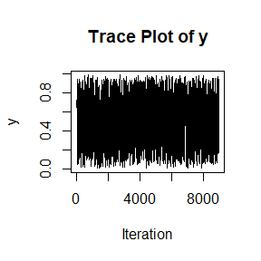

```r
# Parameters
n <- 10         # Number of trials in Binomial distribution
a <- 2          # Parameter 'a' for Beta distribution
b <- 2          # Parameter 'b' for Beta distribution
n_iter <- 10000 # Number of iterations for the Gibbs sampler

# Run Gibbs sampler
set.seed(123) # For reproducibility
result <- gibbs_sampler(n, a, b, n_iter)

# Extract chains
x_chain <- result$x_chain
y_chain <- result$y_chain

# Burn-in period (optional)
burn_in <- 1000
x_chain_burned <- x_chain[(burn_in + 1):n_iter]
y_chain_burned <- y_chain[(burn_in + 1):n_iter]

# Plot results
# Trace plot for y
plot(y_chain_burned, type = "l",
     main = "Trace Plot of y",
     xlab = "Iteration",
     ylab = "y")
```

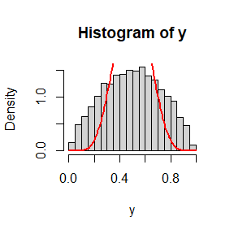

```r
# Histogram for y
hist(y_chain_burned, breaks = 30,
     main = "Histogram of y",
     xlab = "y",
     probability = TRUE)

# Overlay the theoretical Beta density
curve(dbeta(x, mean(x_chain_burned) + a, (n - mean(x_chain_burned)) + b),
      add = TRUE, col = "red", lwd = 2)
```

```r
# Summary statistics
cat("Summary of y_chain:\n")
```

```
#> Summary of y_chain:
```

```r
print(summary(y_chain_burned))
```

```
#>     Min.  1st Qu.   Median     Mean  3rd Qu.     Max.
#> 0.003897 0.325349 0.500766 0.499826 0.673048 0.989291
```

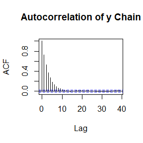

```r
# Autocorrelation plot for y
acf(y_chain_burned, main = "Autocorrelation of y Chain")
```

## Question 9.8

Consider the bivariate density
$$f(x, y) \propto \binom{n}{x} y^{x+a-1}(1-y)^{n-x+b-1}, \quad x = 0, 1,
\ldots, n, \quad 0 \leq y \leq 1.$$

It can be shown (see e.g. ) that for fixed $a$, $b$, and $n$, the conditional distributions are $\text{Binomial}(n, y)$ and $\text{Beta}(x + a, n - x + b)$. Use the Gibbs sampler to generate a chain with the target joint density $f(x, y)$.

```r
 # Load necessary library
library(Rcpp)

# Define the Gibbs sampler function using Rcpp
Rcpp::cppFunction('
#include <Rcpp.h>
using namespace Rcpp;
// [[Rcpp::export]]
List gibbs_sampler(int n, double a, double b, int n_iter) {
  IntegerVector x_chain(n_iter);
  NumericVector y_chain(n_iter);

  // Initial values
  int x = n / 2; // Initial value for x
  double y = 0.5; // Initial value for y

  for (int i = 0; i < n_iter; i++) {
    // Sample x | y from Binomial(n, y)
    x = R::rbinom(n, y);
    // Sample y | x from Beta(x + a, n - x + b)
    y = R::rbeta(x + a, n - x + b);
    // Store values in the chains
    x_chain[i] = x;
    y_chain[i] = y;
  }

  // Return the generated chains as a list
  return List::create(
    Named("x_chain") = x_chain,
    Named("y_chain") = y_chain
  );
}
')
```

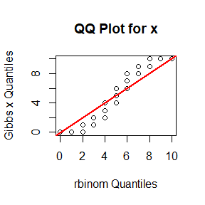

```r
# Parameters
n <- 10
a <- 2
b <- 2
n_iter <- 10000
burn_in <- 1000

# Run Gibbs sampler
set.seed(123)
result <- gibbs_sampler(n, a, b, n_iter)

# Extract chains and remove burn-in
x_chain <- result$x_chain[(burn_in + 1):n_iter]
y_chain <- result$y_chain[(burn_in + 1):n_iter]

# Generate random numbers using R's built-in functions
set.seed(123)
x_rbinom <- rbinom(length(x_chain), size = n, prob = mean(y_chain))
y_rbeta <- rbeta(length(y_chain), shape1 = mean(x_chain) + a, shape2 = (n - mean(x_chain)) + b)

# QQ plot for x
qqplot(x_rbinom, x_chain, main = "QQ Plot for x", xlab = "rbinom Quantiles", ylab = "Gibbs x Quantiles")
abline(0, 1, col = "red", lwd = 2)
```

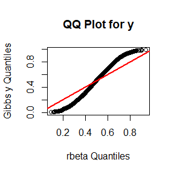

```r
# QQ plot for y
qqplot(y_rbeta, y_chain, main = "QQ Plot for y", xlab = "rbeta Quantiles", ylab = "Gibbs y Quantiles")
abline(0, 1, col = "red", lwd = 2)
```

## Answer 9.8

```r
 # Load necessary libraries
library(Rcpp)
library(ggplot2)
library(microbenchmark)

# Define the Gibbs sampler function using Rcpp
cppFunction('
#include <Rcpp.h>
using namespace Rcpp;
// [[Rcpp::export]]
NumericMatrix gibbsSamplerRcpp(int n, double a, double b, int N, int burn_in) {
  NumericMatrix samples(N, 2);
  int x = n / 2; // Initial value of x
  double y = 0.5; // Initial value of y
  for (int t = 0; t < N + burn_in; ++t) {
    // Sample x | y
    x = R::rbinom(n, y);
    // Sample y | x
    y = R::rbeta(x + a, n - x + b);
    // Store samples after burn-in period
    if (t >= burn_in) {
      samples(t - burn_in, 0) = x;
      samples(t - burn_in, 1) = y;
    }
  }
  return samples;
}
')
# Gibbs sampler function in R
gibbsSamplerR <- function(n, a, b, N, burn_in) {
  samples <- matrix(0, nrow = N, ncol = 2)
  x <- floor(n / 2) # Initial value of x
  y <- 0.5          # Initial value of y
  for (t in 1:(N + burn_in)) {
    # Sample x | y
    x <- rbinom(1, n, y)
    # Sample y | x
    y <- rbeta(1, x + a, n - x + b)
    # Store samples after burn-in
    if (t > burn_in) {
      samples[t - burn_in, ] <- c(x, y)
    }
  }
  colnames(samples) <- c("x", "y")
  return(samples)
}

# Parameters
n <- 10      # Number of trials
a <- 2       # Beta parameter a
b <- 2       # Beta parameter b
N <- 10000   # Number of samples to generate
burn_in <- 1000 # Burn-in period

set.seed(123) # For reproducibility

# Benchmarking
benchmark_results <- microbenchmark(
  gibbs_Rcpp = gibbsSamplerRcpp(n, a, b, N, burn_in),
  gibbs_R = gibbsSamplerR(n, a, b, N, burn_in),
  times = 10
)

# Print benchmark results
print(benchmark_results)
```

```
#> Unit: milliseconds
#>        expr       min      lq      mean    median        uq       max neval
#>  gibbs_Rcpp  2.000701  2.0060  2.103521  2.019901  2.076102  2.754701    10
#>     gibbs_R 16.482301 17.0307 19.091131 19.139750 21.062101 22.025101    10
```

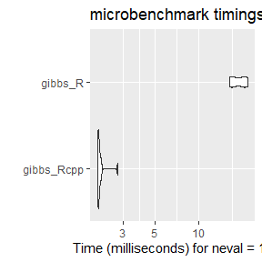

```r
# Visualize benchmark results
autoplot(benchmark_results)
```

```r
# Calculate speed-up factor
speedup <- mean(benchmark_results$time[benchmark_results$expr == "gibbs_R"]) /
           mean(benchmark_results$time[benchmark_results$expr == "gibbs_Rcpp"])
speedup_factor <- speedup
cat("Speedup Factor:", speedup_factor, "\n")
```

```
#> Speedup Factor: 9.075798
```

## References

- Rafael Díaz. (2024). Gibbs sampler bivariate normal in Rcpp. Stack Overflow. https://stackoverflow. com/questions/50362985/gibbs-sampler-bivariate-normal-in-rcpp
- Thinking inside the box. (2011). MCMC and faster Gibbs Sampling using Rcpp | R-bloggers. R bloggers. https://www.r-bloggers.com/2011/07/mcmc-and-faster-gibbs-sampling-using-rcpp